Zum Hauptinhalt springen

# 16 Probeklausur

Schlüsselwörter

Statistik, Bayes, Wahrscheinlichkeit, Inferenz, R, Kausalität

Diese Liste ist im Aufbau. Bitte konsultieren Sie für weitere Aufgaben selbständig alle relevanten Aufgaben, die in den Kapiteln vorgestellt wurden.

## 16.1 2026

Hier finden Sie Single-Choice-Aufgaben zu einer Probeklausur aus dem Jahr 2026. Sie decken die Kapitel von den Zielarten der Statistik bis zum Befragen der Post-Verteilung ab und sind nach Kapiteln geordnet. Alle Aufgaben lassen sich mit Papier und Stift lösen; für einige Rechenaufgaben (z. B. Binomialwahrscheinlichkeiten) brauchen Sie einen Taschenrechner. Wählen Sie eine Antwort aus und klicken Sie auf das Häkchen, um sie zu überprüfen; über das Fragezeichen erhalten Sie die ausführliche Lösung.

Im Kausalmodell zu Studie B (Blutdruck) hat das Medikament (`drug`) keinen direkten Effekt auf die Heilung (`recovery`), sondern zwei indirekte Effekte: einen heilsamen Effekt über die Blutdrucksenkung (`pressure`) und einen schädlichen, toxischen Effekt (`toxic`). Warum liefert die Betrachtung der nach Blutdruck stratifizierten Teildaten hier ein irreführendes Bild – anders als das Stratifizieren nach Geschlecht in Studie A?

Weil die Stichprobengröße in Studie B mit $n=700$ zu klein ist, um stratifizierte Analysen sinnvoll durchzuführen.Weil man beim Stratifizieren nach Blutdruck automatisch auch nach Geschlecht kontrolliert, was die Ergebnisse zusätzlich verzerrt.Weil Blutdruck in dieser Studie ein reiner *Confounder* ist, der sowohl das Medikament als auch die Heilung unabhängig voneinander beeinflusst – genau wie das Geschlecht in Studie A.Weil Blutdruck hier ein *Mediator* auf einem Wirkungspfad des Medikaments ist: Konditioniert man auf den Blutdruck, wird der darüber laufende heilsame Effekt des Medikaments “weggerechnet”, sodass nur noch der toxische Pfad sichtbar bleibt.Weil das Medikament in Wirklichkeit gar keinen Effekt auf die Heilung hat und alle beobachteten Unterschiede rein zufällig zustande kommen.

Im DAG zu Studie B gilt: `drug -> pressure -> recovery` (heilsamer, indirekter Pfad) und `drug -> toxic -> recovery` (schädlicher, indirekter Pfad); es gibt keinen direkten Pfeil von `drug` zu `recovery`. Blutdruck (`pressure`) liegt hier also *auf dem Kausalpfad* zwischen Medikament und Heilung – er ist ein *Mediator*, keine Drittvariable, die unabhängig vom Medikament wirkt. Stratifiziert (konditioniert) man auf den Blutdruck, “blockiert” man damit den heilsamen Pfad über die Blutdrucksenkung: Innerhalb einer Blutdruck-Schicht kann sich das Medikament nur noch über den toxischen Pfad bemerkbar machen, weshalb in den Teildaten ausschließlich der schädliche Effekt sichtbar wird. Das entspricht der ersten Antwortoption.

Warum die Distraktoren falsch sind:

- Die zweite Option verwechselt genau die beiden Rollen, die im Kapitel gegenübergestellt werden: In Studie A ist Geschlecht ein *Confounder* (eine gemeinsame Ursache von Medikamenteneinnahme und Heilung, die *nicht* auf dem Wirkungspfad des Medikaments liegt) – dort ist Stratifizieren richtig. In Studie B ist Blutdruck dagegen ein *Mediator* auf dem Wirkungspfad selbst – dort verzerrt Stratifizieren das Bild. Beide als gleichartig (“wie in Studie A”) zu behandeln, ist genau der Fehler, den das Kapitel vermeiden will.
- Die Stichprobengröße ($n=700$ in beiden fiktiven Studien) wird im Kapitel nicht als Grund für die Irreführung genannt; das Problem ist struktureller (kausaler), nicht statistischer Natur im Sinne der Fallzahl.
- Das Kapitel zeigt gerade, dass das Medikament *zwei* reale, aber gegenläufige Effekte hat (toxisch und heilsam) – nicht, dass gar kein Effekt vorliegt und alles Zufall wäre.
- Das Kausalmodell zu Studie B enthält keine Geschlechtsvariable; die Aussage, man kontrolliere “automatisch” auch nach Geschlecht, ist im Modell nicht angelegt und frei erfunden.
- Falsch
- Falsch
- Falsch
- Wahr
- Falsch

Welche der folgenden Aussagen beschreibt einen im Kapitel dargestellten, zutreffenden Unterschied zwischen frequentistischer und Bayes-Inferenz?

Die Bayes-Inferenz definiert Wahrscheinlichkeit stets über relative Häufigkeiten bei (gedanklich) unendlicher Wiederholung, der Frequentismus über subjektives Vorwissen.In beiden Ansätzen sind direkte Wahrscheinlichkeitsaussagen über Hypothesen oder Parameter möglich; sie unterscheiden sich nur in der Berechnungsmethode.Beide Ansätze kommen bei denselben Daten immer zu identischen inhaltlichen Schlussfolgerungen, da sie auf denselben Rohdaten beruhen.In der Bayes-Inferenz fließt Vorwissen (Priori-Wissen) explizit in die Analyse ein, und es sind Wahrscheinlichkeitsaussagen über Hypothesen möglich; im Frequentismus ist beides nicht vorgesehen.Der Frequentismus berücksichtigt explizit Vorwissen über den untersuchten Sachverhalt, die Bayes-Inferenz hingegen nicht.

Laut Kapitel unterscheiden sich Frequentismus und Bayes-Inferenz insbesondere darin, dass (a) die Bayes-Inferenz Vorwissen (Priori-Wissen) explizit und kritisierbar in die Analyse einbezieht, während der Frequentismus dies nicht tut, und (b) nur die Bayes-Inferenz direkte Wahrscheinlichkeitsaussagen über Hypothesen (bzw. Parameter) erlaubt, während der Frequentismus stattdessen angibt, wie häufig eine vergleichbare Datenlage bei (gedanklich) unendlicher Wiederholung zu erwarten wäre. Das entspricht der ersten Antwortoption.

Warum die Distraktoren falsch sind:

- Die zweite Option kehrt den Sachverhalt genau um: Es ist die Bayes-Inferenz, die Vorwissen explizit berücksichtigt (über die Priori-Verteilung), nicht der Frequentismus.
- Die dritte Option ist falsch, weil gerade dieser Punkt – ob Wahrscheinlichkeitsaussagen über Hypothesen/Parameter erlaubt sind – der entscheidende konzeptuelle (nicht nur rechnerische) Unterschied zwischen beiden Ansätzen ist.
- Die vierte Option vertauscht die Definitionen: Der *Frequentismus* definiert Wahrscheinlichkeit über relative Häufigkeiten bei (gedanklich) unendlicher Wiederholung; die Bayes-Statistik lässt daneben auch subjektives Vorwissen (Priori) als Wahrscheinlichkeit zu.
- Die fünfte Option ist falsch, da beide Ansätze – je nach gewähltem Modell bzw. Priori – durchaus zu unterschiedlichen Schlussfolgerungen (z. B. unterschiedlichen Interpretationen von Signifikanz oder Unsicherheit) gelangen können, auch bei identischen Rohdaten.
- Falsch
- Falsch
- Falsch
- Wahr
- Falsch

Gegeben ist ein Konfidenzintervall der Art `95% CI [182cm; 184cm]` für einen Populationsparameter (z. B. $\mu$). Wie ist die folgende Interpretation dieses Intervalls einzuordnen?

> Würde man die Studie sehr oft wiederholen, würden 95% der entstehenden Konfidenzintervalle den wahren Wert beinhalten.

Passt nur zur Bayesianischen, nicht zur Frequentistischen StatistikPasst nur zur Frequentistischen, nicht zur Bayesianischen StatistikPasst sowohl zur Frequentistischen, als auch zur Bayesianischen StatistikPasst weder zur Frequentistischen, noch zur Bayesianischen Statistik

2. Passt nur zur Frequentistischen, nicht zur Bayesianischen Statistik

Die Aussage argumentiert über (gedachte) sehr häufige Wiederholung der Studie, also über Wahrscheinlichkeit als relative Häufigkeit. Das ist die frequentistische Sichtweise: Die 95 % beziehen sich auf das Verfahren, nicht auf den einen berechneten Bereich.

Die Bayes-Statistik interpretiert einen Schätzbereich anders: Mit 95 % Wahrscheinlichkeit liegt der Parameter in diesem Bereich (gegeben Daten und Modell). Diese Aussage ist frequentistisch nicht zulässig, und die Wiederholungs-Aussage ist umgekehrt keine Bayes-Interpretation.

Aufgabenname: `interpret-ci2`

- Falsch
- Richtig
- Falsch
- Falsch

Zwei Forschende schätzen je ein Regressionsmodell zur Vorhersage von Klausurpunkten anhand der Lernzeit.

- **Modell A** hat ein sehr *enges* Konfidenzintervall für die Steigung $\beta_1$, aber die einzelnen Datenpunkte streuen recht stark um die Regressionsgerade (kleines $R^2$, großes $\sigma$).
- **Modell B** hat ein *breites* Konfidenzintervall für $\beta_1$, aber die Datenpunkte liegen sehr nah an der Regressionsgeraden (großes $R^2$, kleines $\sigma$).

Welche Aussage zu den zwei Arten der Ungewissheit (Ungewissheit zur Regressionsgeraden vs. Ungewissheit zur Vorhersagegenauigkeit) trifft zu?

Beide Modelle weisen bzgl. $\beta$ und $\sigma$ die gleiche Ungewissheit auf, da Konfidenzintervall-Breite und Streuung der Residuen dasselbe messen.Die Breite des Konfidenzintervalls für $\beta_1$ hängt ausschließlich von $\sigma$ ab, die Stichprobengröße spielt dabei keine Rolle.Modell A hat sowohl bzgl. $\beta$ als auch bzgl. $\sigma$ eine höhere Ungewissheit als Modell B.$R^2$ und $\sigma$ sind zwei völlig unabhängige, unverwandte Kennwerte ohne inhaltlichen Zusammenhang.Modell A hat eine geringe Ungewissheit bzgl. der Lage der Regressionsgeraden ($\beta$), aber eine hohe Ungewissheit bzgl. der Vorhersagegenauigkeit einzelner Werte ($\sigma$); bei Modell B ist es umgekehrt.

Das Kapitel unterscheidet zwei Arten von Ungewissheit im Regressionsmodell: (1) Ungewissheit zu den *Regressionsgewichten* ($\beta_0$, $\beta_1$; ausgedrückt z. B. über die Breite ihrer Konfidenzintervalle) und (2) Ungewissheit zur *Vorhersagegenauigkeit* (ausgedrückt über $\sigma$ bzw. $R^2$). Diese beiden Ungewissheiten sind grundsätzlich unabhängig voneinander: Ein Modell kann die Lage der Regressionsgeraden sehr genau kennen (enges Konfidenzintervall für $\beta$), aber trotzdem einzelne Werte nur ungenau vorhersagen (großes $\sigma$) – und umgekehrt. Genau das ist bei Modell A (enges $\beta$-KI, aber großes $\sigma$) und Modell B (breites $\beta$-KI, aber kleines $\sigma$) der Fall. Die erste Antwortoption beschreibt das korrekt.

Warum die Distraktoren falsch sind:

- Konfidenzintervall-Breite (Ungewissheit über $\beta$) und Residualstreuung (Ungewissheit über $\sigma$) messen *unterschiedliche* Dinge; sie können unabhängig voneinander groß oder klein sein, wie das Beispiel zeigt. Die zweite Option unterstellt fälschlich, beide seien identisch.
- Die dritte Option widerspricht direkt der Aufgabenstellung: Modell A hat gerade ein *engeres* $\beta$-Konfidenzintervall als Modell B, also nicht durchgängig mehr Ungewissheit.
- Die Breite des Konfidenzintervalls für $\beta_1$ hängt zwar auch von $\sigma$ ab, aber ebenso von der Stichprobengröße (größere Stichproben führen tendenziell zu engeren Konfidenzintervallen) sowie von der Streuung der UV. Die vierte Option ist daher eine unzulässige Vereinfachung.
- $R^2$ und $\sigma$ sind laut Kapitel zwei Kennwerte, “die die gleiche Aussage machen” – sie hängen also eng zusammen (beide quantifizieren die Vorhersagegüte/den Vorhersagefehler). Die fünfte Option behauptet das Gegenteil.
- Falsch
- Falsch
- Falsch
- Falsch
- Wahr

Beim einfachen Würfelwurf betrachten wir die Ereignisse $A$ = “gerade Augenzahl” ($A=\{2,4,6\}$) und $C$ = “Augenzahl mindestens 5” ($C=\{5,6\}$). Sind $A$ und $C$ disjunkt?

Ja, $A$ und $C$ sind disjunkt, da $A \cap C = \emptyset$.Diese Frage lässt sich nicht beantworten, ohne die Wahrscheinlichkeiten von $A$ und $C$ zu kennen.Ja, $A$ und $C$ sind disjunkt, weil es sich um zwei unterschiedlich definierte Ereignisse handelt.Nein, $A$ und $C$ sind nicht disjunkt, weil $A \cup C \neq \Omega$ gilt.Nein, $A$ und $C$ sind nicht disjunkt, da $A \cap C = \{6\} \neq \emptyset$.

Zwei Ereignisse sind per Definition genau dann disjunkt, wenn ihre Schnittmenge leer ist: $A \cap C = \emptyset$. Hier gilt $A = \{2,4,6\}$ und $C = \{5,6\}$; die Zahl $6$ ist Element *beider* Mengen, also $A \cap C = \{6\} \neq \emptyset$. Damit sind $A$ und $C$ *nicht* disjunkt – sie überschneiden sich im Elementarereignis “6”. Die erste Antwortoption ist korrekt.

Warum die Distraktoren falsch sind:

- Die zweite Option behauptet fälschlich $A \cap C = \emptyset$; das Element $6$ liegt aber offensichtlich in beiden Mengen, wie eine einfache Probe zeigt ($6$ ist gerade, und $6 \ge 5$).
- Die dritte Option verwechselt Disjunktheit mit bloßer *unterschiedlicher Definition* oder Benennung zweier Ereignisse: Zwei Ereignisse können unterschiedlich definiert sein und sich trotzdem überschneiden (wie hier). Disjunktheit ist eine Eigenschaft der zugrundeliegenden *Mengen* (leere Schnittmenge), nicht der Wortwahl ihrer Definition.
- Die vierte Option zieht das falsche Kriterium heran: Ob $A \cup C = \Omega$ gilt (Vollständigkeit der Zerlegung) ist eine andere Frage als die nach der Disjunktheit ($A \cap C = \emptyset$). Beide Eigenschaften sind unabhängig voneinander zu prüfen.
- Die fünfte Option ist falsch, weil Disjunktheit eine rein mengentheoretische Eigenschaft ist (überschneiden sich die Mengen der Elementarereignisse oder nicht?) und keine Kenntnis von Wahrscheinlichkeiten erfordert.
- Falsch
- Falsch
- Falsch
- Falsch
- Wahr

Seien $A$ und $B$ zwei disjunkte Ereignisse. Welche der folgenden Zuordnungen von Wahrscheinlichkeiten zu $A$, $B$ und $A \cup B$ ist mit *allen drei* Kolmogorov-Axiomen (Nichtnegativität, Normierung, Additivität) vereinbar?

$Pr(A) = 0.3$, $Pr(B) = 0.4$, $Pr(A \cup B) = 0.5$$Pr(A) = 0.3$, $Pr(B) = 0.4$, $Pr(A \cup B) = 0.7$$Pr(A) = 0.6$, $Pr(B) = 0.6$, $Pr(A \cup B) = 1.2$$Pr(\Omega) = 0.9$, $Pr(A) = 0.3$, $Pr(B) = 0.4$$Pr(A) = -0.2$, $Pr(B) = 0.5$, $Pr(A \cup B) = 0.3$

Für disjunkte Ereignisse fordert das *Additivitätsaxiom*, dass $Pr(A \cup B) = Pr(A) + Pr(B)$ gilt. Zusätzlich müssen alle Wahrscheinlichkeiten nichtnegativ sein (*Nichtnegativität*) und dürfen den Wert 1 nicht überschreiten, insbesondere gilt $Pr(\Omega)=1$ (*Normierung*). Bei $Pr(A)=0.3$, $Pr(B)=0.4$ und $Pr(A \cup B)=0.7$ ist $0.3+0.4=0.7$ (Additivität erfüllt), alle Werte liegen zwischen 0 und 1 (Nichtnegativität und Normierung erfüllt). Diese Zuordnung verletzt kein Axiom, die erste Antwortoption ist daher korrekt.

Warum die Distraktoren falsch sind:

- Bei der zweiten Option müsste laut Additivität $Pr(A \cup B) = 0.3+0.4 = 0.7$ gelten, angegeben ist aber $0.5$ – das *Additivitätsaxiom* ist verletzt.
- Die dritte Option gibt $Pr(A) = -0.2$ an; negative Wahrscheinlichkeiten sind nicht erlaubt – das *Nichtnegativitätsaxiom* ist verletzt.
- Bei der vierten Option ergibt sich zwar additiv $0.6+0.6=1.2$, doch eine Wahrscheinlichkeit von $1.2$ überschreitet den zulässigen Maximalwert von $1$ (das sichere Ereignis $\Omega$ hat höchstens Wahrscheinlichkeit 1) – das *Normierungsaxiom* ist verletzt.
- Die fünfte Option gibt $Pr(\Omega) = 0.9$ an; nach dem Normierungsaxiom muss aber $Pr(\Omega) = 1$ gelten (das sichere Ereignis hat immer Wahrscheinlichkeit 1) – auch hier ist das *Normierungsaxiom* verletzt.
- Falsch
- Wahr
- Falsch
- Falsch
- Falsch

Die Wartezeit $X$ auf einen Bus sei gleichverteilt zwischen 0 und 10 Minuten, mit konstanter Wahrscheinlichkeitsdichte $f(x) = 1/10$ für $0 < x < 10$. Welche der folgenden Aussagen zur stetigen Zufallsvariable $X$ ist korrekt?

$Pr(X=3) = f(3) = 0.1$.Da $Pr(X=3) = 0$ ist, muss auch die Wahrscheinlichkeitsdichte $f(3) = 0$ sein.$Pr(0 < X < 5) = 0$, da alle einzelnen Punktwahrscheinlichkeiten in diesem Intervall Null sind.Da $X$ stetig ist, lässt sich für $X$ grundsätzlich keine sinnvolle Wahrscheinlichkeitsaussage treffen.$Pr(X=3) = 0$, obwohl die Wahrscheinlichkeitsdichte an der Stelle $x=3$ den positiven Wert $f(3) = 0.1$ hat.

Bei einer stetigen Zufallsvariable ist die Wahrscheinlichkeit für einen *einzelnen, exakten* Punkt stets Null, $Pr(X=x_j)=0$ – unabhängig davon, wie “wahrscheinlich” dieser Bereich intuitiv erscheint. Das liegt daran, dass die Fläche unter der Dichtefunktion über einem einzelnen Punkt (einem Intervall der Breite Null) immer Null ist. Die *Dichte* $f(x)$ hingegen ist ein davon zu unterscheidender Begriff: Sie gibt an, wie “dicht” die Wahrscheinlichkeitsmasse an einer Stelle ist, und kann durchaus positiv sein, auch wenn die zugehörige Punktwahrscheinlichkeit Null ist. Hier gilt $Pr(X=3)=0$, aber $f(3)=0.1>0$. Die erste Antwortoption gibt das korrekt wieder.

Warum die Distraktoren falsch sind:

- Die zweite Option verwechselt *Wahrscheinlichkeit eines Punktes* ($Pr(X=3)=0$) mit der *Dichte an diesem Punkt* ($f(3)$). Beide Konzepte sind unterschiedlich: Die Dichte kann an praktisch jeder Stelle positiv sein, obwohl die Punktwahrscheinlichkeit überall Null ist – genau das ist die Besonderheit stetiger Zufallsvariablen.
- Die dritte Option setzt Dichte und Wahrscheinlichkeit gleich ($Pr(X=3)=f(3)$); das ist nur für Intervalle (über Integration/Fläche) sinnvoll anwendbar, nicht für einzelne Punkte, deren Wahrscheinlichkeit stets Null ist.
- Die vierte Option ist falsch, weil für stetige Zufallsvariablen sehr wohl sinnvolle Wahrscheinlichkeitsaussagen möglich sind – allerdings nur für *Intervalle* (z. B. $Pr(0<X<5)$), nicht für einzelne Punkte.
- Die fünfte Option begeht einen Fehlschluss: Aus der Tatsache, dass jeder *einzelne* Punkt im Intervall die Wahrscheinlichkeit Null hat, folgt *nicht*, dass auch das gesamte *Intervall* die Wahrscheinlichkeit Null hat. Tatsächlich ist $Pr(0<X<5) = 5 \cdot f(x) = 5 \cdot 0.1 = 0.5$ (50 %), wie im Kapitel am Busbeispiel gezeigt.
- Falsch
- Falsch
- Falsch
- Falsch
- Wahr

Wann darf man bei der Berechnung von $Pr(A \cup B)$ die vereinfachte Formel $Pr(A \cup B) = Pr(A) + Pr(B)$ (ohne Abzug des Schnitts) verwenden?

Nur wenn $Pr(A) = Pr(B)$ gilt.Nur wenn $A$ und $B$ ein vollständiges Ereignissystem bilden.Nur wenn $A$ und $B$ disjunkt sind, also $A \cap B = \emptyset$ gilt.Nur wenn $A$ und $B$ stochastisch unabhängig sind.Immer, unabhängig von der Beziehung zwischen $A$ und $B$.

Der *allgemeine* Additionssatz lautet $Pr(A \cup B) = Pr(A) + Pr(B) - Pr(A \cap B)$. Die vereinfachte Formel $Pr(A \cup B) = Pr(A) + Pr(B)$ ergibt sich daraus genau dann, wenn der Korrekturterm $Pr(A \cap B) = 0$ ist – und das ist per Definition genau dann der Fall, wenn $A$ und $B$ *disjunkt* sind ($A \cap B = \emptyset$). Die erste Antwortoption benennt exakt diese Bedingung.

Warum die Distraktoren falsch sind:

- Die vereinfachte Formel gilt *nicht* immer – überlappen sich $A$ und $B$ (also $A \cap B \neq \emptyset$), würde der gemeinsame Bereich doppelt gezählt und das Ergebnis wäre zu groß.
- Stochastische *Unabhängigkeit* ist eine andere Eigenschaft als *Disjunktheit* und liefert gerade *keine* Vereinfachung des Additionssatzes: Bei unabhängigen Ereignissen gilt zwar $Pr(A \cap B) = Pr(A) \cdot Pr(B)$, dieser Term muss aber trotzdem vom Additionssatz abgezogen werden (außer er ist zufällig Null, was bei unabhängigen Ereignissen mit positiver Wahrscheinlichkeit gerade *nicht* der Fall ist). Unabhängigkeit und Disjunktheit dürfen nicht verwechselt werden.
- Die Bedingung $Pr(A) = Pr(B)$ hat nichts mit der Frage zu tun, ob sich $A$ und $B$ überschneiden – zwei gleich wahrscheinliche Ereignisse können sich durchaus überlappen.
- Ein *vollständiges Ereignissystem* verlangt zusätzlich zur Disjunktheit auch, dass $A \cup B = \Omega$ gilt – das ist eine strengere, hier nicht notwendige Zusatzbedingung. Für die vereinfachte Additionsformel reicht bereits die reine Disjunktheit aus, ganz unabhängig davon, ob $A$ und $B$ den gesamten Ergebnisraum abdecken.
- Falsch
- Falsch
- Wahr
- Falsch
- Falsch

Gegeben sind zwei Ereignisse $A$ und $B$ mit $Pr(A) > 0$ und $Pr(B) > 0$. Welche Aussage zu bedingten und gemeinsamen Wahrscheinlichkeiten trifft zu?

$Pr(A|B) = Pr(B|A)$ gilt genau dann, wenn $A$ und $B$ unabhängig sind.Stets gilt sowohl $Pr(A|B) = Pr(B|A)$ als auch $Pr(AB) = Pr(BA)$.Im Allgemeinen gilt $Pr(A|B) \ne Pr(B|A)$, aber stets gilt $Pr(AB) = Pr(BA)$.Stets gilt $Pr(A|B) = Pr(B|A)$, aber im Allgemeinen gilt $Pr(AB) \ne Pr(BA)$.Im Allgemeinen gilt sowohl $Pr(A|B) \ne Pr(B|A)$ als auch $Pr(AB) \ne Pr(BA)$.

$Pr(AB)$ ist die Wahrscheinlichkeit, dass $A$ *und* $B$ gemeinsam eintreten. Ob man “A und B” oder “B und A” sagt, ist dasselbe Ereignis; daher gilt stets $Pr(AB) = Pr(BA)$ (Symmetrie der gemeinsamen Wahrscheinlichkeit).

Für die bedingten Wahrscheinlichkeiten gilt dagegen

$$Pr(A|B) = \frac{Pr(AB)}{Pr(B)}, \qquad Pr(B|A) = \frac{Pr(AB)}{Pr(A)}.$$

Der Zähler ist gleich, der Nenner aber verschieden. Die beiden bedingten Wahrscheinlichkeiten sind daher nur gleich, wenn $Pr(A) = Pr(B)$ (oder $Pr(AB) = 0$). Im Allgemeinen gilt $Pr(A|B) \ne Pr(B|A)$. Beispiel: Die Wahrscheinlichkeit für Wolken, gegeben Regen, ist fast 1; die Wahrscheinlichkeit für Regen, gegeben Wolken, ist deutlich kleiner.

Warum die Distraktoren falsch sind:

- Die zweite Option vertauscht die beiden Eigenschaften: Symmetrisch ist die gemeinsame, nicht die bedingte Wahrscheinlichkeit.
- Die dritte Option hält auch die bedingte Wahrscheinlichkeit für symmetrisch. Das ist der klassische Fehler, $Pr(A|B)$ mit $Pr(B|A)$ zu verwechseln.
- Die vierte Option bestreitet die Symmetrie der gemeinsamen Wahrscheinlichkeit; $AB$ und $BA$ sind aber dasselbe Ereignis.
- Die fünfte Option: Bei Unabhängigkeit gilt $Pr(A|B) = Pr(A)$ und $Pr(B|A) = Pr(B)$. Diese sind nur gleich, wenn $Pr(A) = Pr(B)$. Unabhängigkeit ist also weder nötig noch ausreichend; entscheidend ist $Pr(A) = Pr(B)$.

Aufgabenname: `bed-wskt-symmetrie-aussagen-schoice`

- Falsch
- Falsch
- Wahr
- Falsch
- Falsch

Von 100 Studierenden haben 80 für eine Klausur gelernt ($L$), 20 nicht ($NL$). Von den Lernenden haben 70 bestanden ($B$) und 10 nicht bestanden ($NB$); von den Nicht-Lernenden haben 6 bestanden und 14 nicht bestanden, s. folgende Tabelle:

| Gruppe | B | NB | Summe |
| --- | --- | --- | --- |
| L (gelernt) | 70 | 10 | 80 |
| NL (nicht gelernt) | 6 | 14 | 20 |
| Summe | 76 | 24 | 100 |

Wie hoch ist $Pr(B \mid NL)$, die Wahrscheinlichkeit zu bestehen, gegeben dass *nicht* gelernt wurde?

$Pr(B \mid NL) = 20/6 \approx 3.33$$Pr(B \mid NL) = 6/100 = 0.06$$Pr(B \mid NL) = 76/100 = 0.76$$Pr(B \mid NL) = 70/80 = 0.875$$Pr(B \mid NL) = 6/20 = 0.3$

Die bedingte Wahrscheinlichkeit $Pr(B \mid NL)$ lässt sich als “gefilterte Tabelle” verstehen: Man beschränkt sich nur auf die Zeile/Spalte, die der Bedingung entspricht (hier: nur die Nicht-Lernenden, $NL$, insgesamt 20 Personen), und bestimmt darin den Anteil der Bestandenen. Von den 20 Nicht-Lernenden haben 6 bestanden, also $Pr(B \mid NL) = 6/20 = 0.3$. Die erste Antwortoption ist korrekt.

Warum die Distraktoren falsch sind:

- Die zweite Option berechnet $6/100$ – das ist die *gemeinsame* (nicht die bedingte) Wahrscheinlichkeit $Pr(B \cap NL)$, bezogen auf *alle* 100 Studierenden statt nur auf die 20 Nicht-Lernenden. Für die bedingte Wahrscheinlichkeit muss aber durch die Gesamtzahl der *Bedingungsgruppe* (hier: $NL$, also 20) geteilt werden, nicht durch die Gesamtzahl aller Studierenden.
- Die dritte Option invertiert den Bruch ($20/6$ statt $6/20$) und liefert damit einen Wert über 1 – ein für eine Wahrscheinlichkeit unzulässiges Ergebnis.
- Die vierte Option berechnet stattdessen $Pr(B \mid L) = 70/80$ – die bedingte Wahrscheinlichkeit für die *Lerner*-Gruppe, nicht für die hier gefragte Gruppe der Nicht-Lerner.
- Die fünfte Option berechnet $Pr(B) = 76/100$, die *unbedingte* Wahrscheinlichkeit des Bestehens über alle Studierenden hinweg, ohne überhaupt nach der Lerngruppe zu filtern bzw. zu bedingen.
- Falsch
- Falsch
- Falsch
- Falsch
- Wahr

Eine Urne enthält 6 Kugeln, davon 4 rote und 2 blaue. Es werden nacheinander 2 Kugeln *ohne Zurücklegen* (ZOZ) gezogen. Wie hoch ist die Wahrscheinlichkeit, dass *beide* gezogenen Kugeln rot sind?

$Pr(R_1 \cap R_2) = \dfrac{4}{6} + \dfrac{3}{5} \approx 1.27$$Pr(R_1 \cap R_2) = \dfrac{4}{6} \cdot \dfrac{3}{6} \approx 0.33$$Pr(R_1 \cap R_2) = \dfrac{4}{6} \cdot \dfrac{3}{5} = 0.4$$Pr(R_1 \cap R_2) = \dfrac{4}{6} \cdot \dfrac{4}{6} \approx 0.44$$Pr(R_1 \cap R_2) = \dfrac{4}{6} \cdot \dfrac{4}{5} \approx 0.53$

Beim Ziehen *ohne Zurücklegen* ändert sich die Zusammensetzung der Urne nach dem ersten Zug, daher sind die beiden Ziehungen *abhängig* voneinander – es muss die Kettenregel $Pr(R_1 \cap R_2) = Pr(R_1) \cdot Pr(R_2 \mid R_1)$ verwendet werden. Für den ersten Zug gilt $Pr(R_1) = 4/6$ (4 von 6 Kugeln sind rot). Ist die erste Kugel rot, bleiben für den zweiten Zug nur noch 5 Kugeln übrig, davon 3 rote: $Pr(R_2 \mid R_1) = 3/5$. Damit: $Pr(R_1 \cap R_2) = \frac{4}{6} \cdot \frac{3}{5} = \frac{12}{30} = 0.4$. Die erste Antwortoption ist korrekt.

Warum die Distraktoren falsch sind:

- Die zweite Option verwendet für den zweiten Zug wieder $4/6$, also dieselbe Wahrscheinlichkeit wie im ersten Zug – das entspräche einem Ziehen *mit* Zurücklegen (unabhängige Ziehungen). Da hier aber *ohne* Zurücklegen gezogen wird, ist die Wahrscheinlichkeit im zweiten Zug von der ersten Ziehung abhängig und muss angepasst werden.
- Die dritte Option addiert die beiden Wahrscheinlichkeiten, statt sie zu multiplizieren – das ist die (hier falsche) Formel für die *Vereinigung* zweier Ereignisse, nicht für die *gemeinsame* (Und-)Wahrscheinlichkeit zweier nacheinander eintretender Ereignisse. Zudem ergibt sich ein Wert über 1, was für eine Wahrscheinlichkeit ohnehin unmöglich ist.
- Die vierte Option behält für den Nenner des zweiten Zugs fälschlich die ursprüngliche Kugelanzahl (6) bei, obwohl nach dem ersten Zug ohne Zurücklegen nur noch 5 Kugeln in der Urne sind. Der Nenner (Gesamtzahl der Kugeln) muss sich beim Ziehen ohne Zurücklegen mit verringern.
- Die fünfte Option vergisst, dass durch den ersten Zug bereits eine *rote* Kugel entnommen wurde – im Zähler des zweiten Bruchs müssten daher nur noch 3 (nicht 4) rote Kugeln stehen, da eine rote Kugel schon gezogen wurde.
- Falsch
- Falsch
- Wahr
- Falsch
- Falsch

Drei Maschinen $M_1, M_2, M_3$ produzieren einen Artikel, mit Produktionsanteilen von 50 %, 30 % bzw. 20 % und Ausschussquoten von 4 %, 8 % bzw. 1 %. Wie hoch ist die *totale* Ausschusswahrscheinlichkeit $Pr(S)$ über alle drei Maschinen hinweg?

$Pr(S) = 0.5 \cdot 0.04 \cdot 0.3 \cdot 0.08 \cdot 0.2 \cdot 0.01 \approx 0.00000096$$Pr(S) = 0.04 + 0.08 + 0.01 = 0.13$$Pr(S) = \dfrac{0.04 + 0.08 + 0.01}{3} \approx 0.0433$$Pr(S) = \max(0.04,\, 0.08,\, 0.01) = 0.08$$Pr(S) = 0.5 \cdot 0.04 + 0.3 \cdot 0.08 + 0.2 \cdot 0.01 = 0.046$

Nach dem Satz der totalen Wahrscheinlichkeit gilt, wenn $M_1, M_2, M_3$ ein vollständiges Ereignissystem bilden (jeder Artikel stammt von genau einer Maschine): $Pr(S) = \sum_{i=1}^{3} Pr(M_i) \cdot Pr(S \mid M_i)$. Man gewichtet also jede Ausschussquote mit dem jeweiligen Produktionsanteil und summiert die drei Produkte: $Pr(S) = 0.5 \cdot 0.04 + 0.3 \cdot 0.08 + 0.2 \cdot 0.01 = 0.02 + 0.024 + 0.002 = 0.046$. Die erste Antwortoption ist korrekt.

Warum die Distraktoren falsch sind:

- Die zweite Option bildet den *unge*wichteten arithmetischen Mittelwert der drei Ausschussquoten und ignoriert dabei, dass die Maschinen *unterschiedlich* viel produzieren. Da $M_1$ mit 50 % deutlich mehr produziert als $M_3$ mit 20 %, muss der Beitrag jeder Maschine entsprechend ihrem Produktionsanteil gewichtet werden – nicht einfach gleich behandelt werden.
- Die dritte Option summiert die drei Ausschussquoten direkt, ohne sie überhaupt mit den Produktionsanteilen zu gewichten – das ergibt zudem einen unplausibel hohen Wert (13 %), der über jeder Einzelquote liegt, obwohl eine totale (gemittelte) Quote nie größer als die größte Einzelquote sein kann.
- Die vierte Option wählt einfach die höchste Einzel-Ausschussquote (die von $M_2$) aus und ignoriert dabei vollständig die Produktionsanteile sowie die Beiträge der anderen beiden Maschinen.
- Die fünfte Option multipliziert alle sechs Werte miteinander – das entspricht keiner sinnvollen Formel der Wahrscheinlichkeitsrechnung für dieses Problem und liefert eine verschwindend kleine, nicht plausible Zahl.
- Falsch
- Falsch
- Falsch
- Falsch
- Wahr

Ein Verein hat 12 Mitglieder. Für einen Ausschuss sollen 5 Mitglieder ausgewählt werden, wobei die Reihenfolge der Auswahl keine Rolle spielt und jedes Mitglied höchstens einmal gewählt werden kann. Wie viele mögliche Ausschüsse gibt es?

$12 - 5 = 7$$\binom{12}{5} = \dfrac{12!}{5!\cdot(12-5)!} = 792$$12^5 = 248\,832$$12\cdot 11\cdot 10\cdot 9\cdot 8 = 95\,040$$\dfrac{12!}{5!} = 3\,991\,680$

Da die Reihenfolge der Auswahl keine Rolle spielt und ohne Zurücklegen gezogen wird (jedes Mitglied kann nur einmal gewählt werden), ist der Binomialkoeffizient das passende Werkzeug: $\binom{12}{5} = \dfrac{12!}{5!\cdot(12-5)!} = \dfrac{12!}{5!\cdot 7!} = 792$.

Warum die Distraktoren falsch sind:

- Die zweite Option ($12\cdot11\cdot10\cdot9\cdot8=95\,040$) zählt die Auswahl *mit* Beachtung der Reihenfolge (also die Permutation $12!/(12-5)!$), vergisst aber, anschließend durch $5!$ zu teilen, um die verschiedenen Reihenfolgen innerhalb ein und derselben Auswahl wieder herauszurechnen.
- Die dritte Option ($12!/5! = 3\,991\,680$) teilt fälschlich nur durch $k!=5!$ und vergisst den Faktor $(n-k)!=7!$ im Nenner der Binomialkoeffizient-Formel.
- Die vierte Option ($12^5$) unterstellt fälschlich, dass mit Zurücklegen und mit Beachtung der Reihenfolge gezogen wird (wie bei 5 unabhängigen Ziehungen aus je 12 Möglichkeiten) – hier wird aber jedes Mitglied höchstens einmal gewählt.
- Die fünfte Option ($12-5=7$) verwechselt die Fragestellung mit einer einfachen Differenz und hat inhaltlich nichts mit der Anzahl der Kombinationsmöglichkeiten zu tun.
- Falsch
- Wahr
- Falsch
- Falsch
- Falsch

In einem Callcenter führt ein Anruf mit einer Wahrscheinlichkeit von 30 % zu einem erfolgreichen Kontakt (der Kunde nimmt ab und das Gespräch kommt zustande). Ein Mitarbeiter führt 8 unabhängige Anrufe durch. Wie groß ist die Wahrscheinlichkeit, dass genau 3 dieser 8 Anrufe erfolgreich sind?

$Pr(X=3) = \binom{8}{3}\cdot 0.3^3 \approx 1.512$$Pr(X=3) = \binom{8}{3}\cdot 0.3^3\cdot 0.7^5 \approx 0.254$$Pr(X\le 3) \approx 0.806$$Pr(X=3) = \dfrac{3}{8} = 0.375$$Pr(X=3) = \binom{8}{3}\cdot 0.7^3\cdot 0.3^5 \approx 0.047$

$X$, die Anzahl erfolgreicher Kontakte bei $n=8$ unabhängigen Versuchen mit Erfolgswahrscheinlichkeit $p=0.3$, ist binomialverteilt: $X\sim\text{Bin}(8, 0.3)$. Gesucht ist die Wahrscheinlichkeit für *genau* 3 Erfolge: $Pr(X=3) = \binom{8}{3}p^3(1-p)^{8-3} = \binom{8}{3}\cdot 0.3^3\cdot 0.7^5 \approx 0.254$ (in R: `dbinom(x = 3, size = 8, prob = 0.3)`).

Warum die Distraktoren falsch sind:

- Die zweite Option vertauscht $p$ und $1-p$ ($0.7^3\cdot 0.3^5$ statt $0.3^3\cdot 0.7^5$) – das entspricht der Wahrscheinlichkeit für 3 *Misserfolge* (statt 5 Misserfolge und 3 Erfolge), nicht für 3 Erfolge.
- Die dritte Option berechnet die *kumulierte* Wahrscheinlichkeit $Pr(X\le 3)$ (mit `pbinom`) statt der Wahrscheinlichkeit für *genau* 3 Erfolge (mit `dbinom`) – die Frage verlangt aber explizit “genau 3”.
- Die vierte Option vergisst den Faktor $(1-p)^{n-k}=0.7^5$ für die 5 Misserfolge; das Ergebnis ist folgerichtig größer als 1 und kann daher schon aus formalen Gründen keine gültige Wahrscheinlichkeit sein.
- Die fünfte Option berechnet naiv einen Anteil $3/8$ und ignoriert dabei vollständig die binomiale Struktur des Problems (Erfolgswahrscheinlichkeit $p$ sowie die Anzahl möglicher Pfade über den Binomialkoeffizienten).
- Falsch
- Wahr
- Falsch
- Falsch
- Falsch

Für welche Kombination von Parametern ist die Binomialverteilung $\text{Bin}(n,p)$ symmetrisch?

Wenn $n$ sehr groß ist – unabhängig vom konkreten Wert von $p$.Wenn $p = 0.5$ ist – unabhängig vom konkreten Wert von $n$.Nur wenn $n$ eine gerade Zahl ist.Nie – die Binomialverteilung ist grundsätzlich rechtssteil (linksgipflig).Immer, unabhängig von den Werten von $n$ und $p$.

Bei $p=0.5$ ist die Wahrscheinlichkeit für einen Treffer genauso groß wie die für eine Niete; die Verteilung der Trefferzahlen ist dann symmetrisch um $n/2$, unabhängig davon, wie groß $n$ konkret ist – die erste Option ist korrekt.

Warum die Distraktoren falsch sind:

- Die zweite Option verwechselt die (näherungsweise) Glockenform der Binomialverteilung für große $n$ (Grenzwertsatz von de Moivre-Laplace, Annäherung an die Normalverteilung) mit echter Symmetrie – bei $p\ne 0.5$ bleibt die Verteilung auch für großes $n$ schief.
- Die dritte Option ist zu pauschal: Bei $p\ne 0.5$ (z. B. $p=0.9$, wie im Server-Beispiel dieses Kapitels) ist die Verteilung deutlich schief, nicht symmetrisch.
- Die vierte Option bringt fälschlich die Parität von $n$ ins Spiel – diese hat mit der Symmetrie der Verteilung nichts zu tun, entscheidend ist allein der Wert von $p$.
- Die fünfte Option widerspricht dem Fall $p=0.5$, bei dem gerade *keine* Schiefe vorliegt; die Binomialverteilung ist also nicht grundsätzlich, sondern nur für $p\ne 0.5$ schief.
- Falsch
- Wahr
- Falsch
- Falsch
- Falsch

Welche Funktion hat die Evidenz $Pr(D)$ in der Bayes-Formel $Pr(H|D) = \dfrac{Pr(H)\cdot Pr(D|H)}{Pr(D)}$?

Sie muss bekannt sein, *bevor* man die Likelihood einer einzelnen Hypothese berechnen kann.Sie gibt an, wie plausibel die beste Hypothese im Vergleich zu allen anderen Hypothesen ist.Sie normiert die Aposteriori-Werte, sodass sich diese über alle Hypothesen zu 1 aufsummieren.Sie verändert die Rangfolge der Hypothesen, also welche Hypothese am plausibelsten ist.Sie ist stets identisch mit der Likelihood der plausibelsten Hypothese.

Die Evidenz ist die Summe aller unstandardisierten Aposteriori-Werte (Priori mal Likelihood) über alle Hypothesen. Sie sorgt dafür, dass die resultierenden standardisierten Aposteriori-Wahrscheinlichkeiten eine “brave, normale” Wahrscheinlichkeitsverteilung bilden, die sich zu 1 aufsummiert – die erste Option ist korrekt.

Warum die Distraktoren falsch sind:

- Die zweite Option beschreibt eher ein Vergleichsmaß zwischen zwei Hypothesen (ähnlich einem Bayes-Faktor), nicht die Funktion der Evidenz: Die Evidenz ist für *alle* Hypothesen ein und derselbe Wert, sie vergleicht also nicht direkt “die beste” mit den anderen.
- Die dritte Option ist falsch: Die Evidenz ist die *Summe* der (mit der Priori-Wahrscheinlichkeit gewichteten) Likelihoods über *alle* Hypothesen, nicht nur die Likelihood einer einzelnen (der plausibelsten) Hypothese.
- Die vierte Option kehrt die tatsächliche Berechnungsreihenfolge um: Man berechnet zunächst die Likelihood für jede einzelne Hypothese und summiert diese (gewichtet mit der Priori-Wahrscheinlichkeit) anschließend zur Evidenz auf – nicht umgekehrt.
- Die fünfte Option ist falsch: Da die Evidenz für alle Hypothesen denselben (konstanten) Wert hat, mit dem geteilt wird, ändert sie nur die *Skalierung* aller Post-Werte gleichermaßen, nicht aber deren *Rangfolge* zueinander.
- Falsch
- Falsch
- Wahr
- Falsch
- Falsch

Bei einem Globusversuch werden $n=10$ Würfe durchgeführt, davon zeigt $W=7$ Mal der Zeigefinger auf Wasser. Wie groß ist die Likelihood für die Hypothese $\pi=0.6$, also $Pr(W=7, n=10\mid \pi=0.6)$?

$Pr(W=6,n=10\mid \pi=0.6) \approx 0.251$$Pr(W=7,n=10\mid \pi=0.6) = \binom{10}{7}\cdot 0.6^7 \approx 3.359$$Pr(W\le 7,n=10\mid \pi=0.6) \approx 0.833$$Pr(W=7,n=10\mid \pi=0.6) = \binom{10}{7}\cdot 0.4^7\cdot 0.6^3 \approx 0.042$$Pr(W=7,n=10\mid \pi=0.6) = \binom{10}{7}\cdot 0.6^7\cdot 0.4^3 \approx 0.215$

Unter der Annahme einer Binomialverteilung (unabhängige, identisch verteilte Würfe) ist die Likelihood für die Hypothese $\pi=0.6$ gegeben die Daten $W=7$, $n=10$: $Pr(W=7,n=10\mid \pi=0.6) = \binom{10}{7}\cdot 0.6^7 \cdot 0.4^3 \approx 0.215$ (in R: `dbinom(x = 7, size = 10, prob = 0.6)`).

Warum die Distraktoren falsch sind:

- Die zweite Option vertauscht $\pi$ und $1-\pi$ ($0.4^7\cdot 0.6^3$ statt $0.6^7\cdot 0.4^3$) – das entspricht der Likelihood für 7 “Land”-Treffer statt 7 “Wasser”-Treffer.
- Die dritte Option berechnet die *kumulierte* Wahrscheinlichkeit $Pr(W\le 7)$ (mit `pbinom`) statt der Likelihood für *genau* dieses eine beobachtete Ergebnis $W=7$ (mit `dbinom`) – für die Likelihood ist aber genau das beobachtete Datum relevant.
- Die vierte Option verwendet den falschen Datenwert ($W=6$ statt der tatsächlich beobachteten $W=7$ Treffer) – die Likelihood muss sich immer auf die *tatsächlich beobachteten* Daten beziehen.
- Die fünfte Option vergisst den Faktor $(1-\pi)^{n-x}=0.4^3$ für die 3 “Land”-Ergebnisse; das Resultat ist folgerichtig größer als 1 und kann daher keine gültige Wahrscheinlichkeit sein.
- Falsch
- Falsch
- Falsch
- Falsch
- Wahr

$Pr(M_2\mid A) = \dfrac{0.053}{0.3\cdot 0.06} \approx 2.944$$Pr(M_2\mid A) = Pr(M_2) = 0.3$$Pr(M_2\mid A) = \dfrac{0.5\cdot 0.03}{0.053} \approx 0.283$$Pr(M_2\mid A) = \dfrac{0.3\cdot 0.06}{0.053} \approx 0.340$$Pr(M_2\mid A) = 0.3\cdot 0.06 = 0.018$

Nach Bayes’ Theorem gilt $Pr(M_2\mid A) = \dfrac{Pr(M_2)\cdot Pr(A\mid M_2)}{Pr(A)} = \dfrac{0.3\cdot 0.06}{0.053} \approx 0.340$.

Warum die Distraktoren falsch sind:

- Die zweite Option berechnet nur den Zähler ($Pr(M_2)\cdot Pr(A|M_2)$), vergisst aber die Division durch die Evidenz $Pr(A)$ – ohne diese Standardisierung ist das Ergebnis keine gültige bedingte Wahrscheinlichkeit.
- Die dritte Option verwendet versehentlich die Werte von Maschine 1 ($Pr(M_1)\cdot Pr(A|M_1)$) statt der von Maschine 2 im Zähler – das beantwortet eine andere Frage, nämlich $Pr(M_1|A)$.
- Die vierte Option kehrt den Bruch um (Evidenz geteilt durch Zähler statt umgekehrt); das Ergebnis ist größer als 1 und kann daher keine gültige Wahrscheinlichkeit sein.
- Die fünfte Option gibt schlicht die *Priori*-Wahrscheinlichkeit $Pr(M_2)=0.3$ zurück, ohne die neue Information (dass das Teil Ausschuss ist) über die Likelihood und die Bayes-Formel überhaupt einzubeziehen.
- Falsch
- Falsch
- Falsch
- Wahr
- Falsch

In einer Bayesbox berechnet man für eine Hypothese $H_i$ den unstandardisierten Aposteriori-Wert $\text{Post}_{\text{unstand}} = Pr(H_i)\cdot L_i = 0.05$. Die Summe aller unstandardisierten Post-Werte über sämtliche Hypothesen (die Evidenz) beträgt $0.2$. Wie groß ist die *standardisierte* Aposteriori-Wahrscheinlichkeit für $H_i$?

$\text{Post} = 1 - 0.05 = 0.95$$\text{Post} = \dfrac{0.2}{0.05} = 4$$\text{Post} = 0.05 \cdot 0.2 = 0.01$$\text{Post} = 0.05$ (keine Standardisierung nötig)$\text{Post} = \dfrac{0.05}{0.2} = 0.25$

Die standardisierte Aposteriori-Wahrscheinlichkeit erhält man, indem man den unstandardisierten Post-Wert einer Hypothese durch die Evidenz (die Summe aller unstandardisierten Post-Werte) teilt: $\text{Post} = \dfrac{\text{Post}_{\text{unstand}}}{\text{Evidenz}} = \dfrac{0.05}{0.2} = 0.25$.

Warum die Distraktoren falsch sind:

- Die zweite Option multipliziert statt zu dividieren – das widerspricht der Standardisierungsformel und würde bei ohnehin schon kleinen Werten zu einer noch kleineren, nicht normierten Zahl führen.
- Die dritte Option kehrt den Bruch um (Evidenz geteilt durch unstandardisierten Post-Wert statt umgekehrt) – das Ergebnis ($4$) ist zudem größer als 1 und kann daher keine gültige Wahrscheinlichkeit sein.
- Die vierte Option ignoriert, dass eine Standardisierung überhaupt nötig ist: Der unstandardisierte Post-Wert ist erst nach Division durch die Evidenz eine echte (auf 1 normierte) Wahrscheinlichkeit.
- Die fünfte Option berechnet das Komplement ($1-0.05$), was inhaltlich nichts mit der Standardisierung anhand der Evidenz zu tun hat.
- Falsch
- Falsch
- Falsch
- Falsch
- Wahr

Im Globusversuch (6 Treffer bei 9 Würfen) liegt die Bayesbox `bayesbox_6w_9v` vor, eine Tabelle mit 11 Zeilen und den Spalten `p_grid` (Gitterwerte des Wasseranteils von 0 bis 1), `prior` (überall 1), `likelihood`, `unstand_post` und `post` (standardisierte Posteriori-Wahrscheinlichkeit).

Aus dieser Tabelle soll eine Stichprobe von 10000 Parameterwerten gezogen werden, deren Verteilung der Post-Verteilung entspricht. Im folgenden Code fehlen zwei Angaben, `___A___` und `___B___`:

```r
samples_6w_9v <-
  bayesbox_6w_9v |>
  slice_sample(
    n = 1e4,
    weight_by = ___A___,
    replace = ___B___) |>
  select(p_grid)
```

Welche Füllung der beiden Lücken ist korrekt?

`A = post`, `B = TRUE``A = p_grid`, `B = TRUE``A = prior`, `B = TRUE``A = p_grid`, `B = FALSE``A = post`, `B = FALSE`

Jede Zeile der Bayesbox soll mit einer Wahrscheinlichkeit gezogen werden, die proportional zu ihrer Posteriori-Wahrscheinlichkeit ist; daher `weight_by = post`. Da 10000 Werte aus nur 11 Zeilen gezogen werden, muss *mit Zurücklegen* gezogen werden (`replace = TRUE`); das hält außerdem die Ziehungswahrscheinlichkeiten während des Ziehens konstant. Die Häufigkeiten der gezogenen `p_grid`-Werte geben dann (bis auf Zufallsschwankung) die Post-Verteilung wieder.

Warum die Distraktoren falsch sind:

- `A = post`, `B = FALSE`: Gewichtung richtig, aber ohne Zurücklegen kann jede der 11 Zeilen höchstens einmal gezogen werden. `slice_sample()` liefert dann höchstens 11 statt 10000 Werte (hier bricht R sogar ab, weil die Gitterwerte 0 und 1 die Post-Wahrscheinlichkeit 0 haben). Eine Stichprobe aus der Post-Verteilung ist das nicht. Wer diese Option wählt, übersieht, dass die Bayesbox nur wenige Gitterwerte hat.
- `A = p_grid`, `B = TRUE`: Hier wird nach dem Parameterwert selbst gewichtet statt nach seiner Wahrscheinlichkeit. Große Wasseranteile würden dann bevorzugt gezogen, unabhängig von den Daten (6 von 9). Verwechslung von *Wert* und *Wahrscheinlichkeit des Werts*.
- `A = prior`, `B = TRUE`: Die Gewichtung nach der Priori liefert eine Stichprobe aus der Priori-Verteilung; da die Priori hier gleichverteilt ist, käme jeder Gitterwert gleich oft vor. Die Daten (Likelihood) gingen gar nicht ein.
- `A = p_grid`, `B = FALSE`: kombiniert beide Fehler: falsche Gewichtung und Ziehen ohne Zurücklegen (das ebenfalls höchstens 11 Werte liefert).

Aufgabenname: `post-stichprobe-luecke-schoice`

- Wahr
- Falsch
- Falsch
- Falsch
- Falsch

Eine Bayesbox enthält folgende (standardisierte) Post-Wahrscheinlichkeiten für ein Gitter von 5 Parameterwerten:

| $p$ (Parameterwert) | 0 | 0.25 | 0.5 | 0.75 | 1 |
| --- | --- | --- | --- | --- | --- |
| Post-Wahrscheinlichkeit | 0.05 | 0.20 | 0.30 | 0.30 | 0.15 |

Wie hoch ist laut dieser Bayesbox die Wahrscheinlichkeit, dass der Parameter $p$ *kleiner als* 0.5 ist, also $Pr(p<0.5)$?

$Pr(p<0.5) = 1 - 0.25 = 0.75$$Pr(p<0.5) = 0.05 + 0.20 + 0.30 = 0.55$$Pr(p<0.5) = 0.20$$Pr(p<0.5) = 0.05 + 0.20 = 0.25$$Pr(p<0.5) = 0.05 + 0.20 + 0.30 + 0.30 + 0.15 = 1$

Um $Pr(p<0.5)$ zu berechnen, summiert man die Post-Wahrscheinlichkeiten aller Parameterwerte, die *echt kleiner* als 0.5 sind – das sind hier $p=0$ und $p=0.25$: $Pr(p<0.5) = 0.05+0.20 = 0.25$.

Warum die Distraktoren falsch sind:

- Die zweite Option summiert zusätzlich noch die Post-Wahrscheinlichkeit von $p=0.5$ selbst mit ein – das entspräche aber $Pr(p\le 0.5)$ (kleiner *oder gleich*), nicht der gefragten strengen Ungleichung $Pr(p<0.5)$.
- Die dritte Option berücksichtigt nur den Wert $p=0.25$ und vergisst den Beitrag von $p=0$.
- Die vierte Option berechnet stattdessen das Komplementärereignis $Pr(p\ge 0.5) = 1-Pr(p<0.5)$, beantwortet also eine andere Frage als die gestellte.
- Die fünfte Option summiert schlicht alle Post-Wahrscheinlichkeiten der gesamten Tabelle auf (was per Definition immer 1 ergeben muss, da es sich um eine vollständige Wahrscheinlichkeitsverteilung handelt), berücksichtigt dabei aber gar nicht die Bedingung $p<0.5$.
- Falsch
- Falsch
- Falsch
- Wahr
- Falsch

Beim Befragen der Post-Verteilung unterscheidet man Fragen nach Wahrscheinlichkeiten (p) und Fragen nach Parameterwerten (Quantilen, q). Welche der folgenden Fragen ist eine Frage vom Typ “q” (Frage nach einem Parameterwert)?

“Mit welcher Wahrscheinlichkeit liegt der Wasseranteil zwischen 0.5 und 0.75?”“Wie hoch ist der Anteil der Stichproben mit einem Wasseranteil kleiner als 0.5?”“Mit welcher Wahrscheinlichkeit liegt der Wasseranteil unter 50 %?”“Welcher Wasseranteil wird mit 95 % Wahrscheinlichkeit nicht überschritten?”“Mit welcher Wahrscheinlichkeit liegt der Wasseranteil über 90 %?”

Bei einer q-Frage sucht man einen *Parameterwert* (hier: einen Wasseranteil), zu dem eine gegebene Wahrscheinlichkeit gehört – man geht also von der Wahrscheinlichkeit aus und sucht den zugehörigen Wert auf der x-Achse (der Skala des Parameters). Genau das leistet die erste Frage: Gegeben ist die Wahrscheinlichkeit (95 %), gesucht ist der zugehörige Parameterwert (Wasseranteil).

Warum die Distraktoren falsch sind:

- Die zweite, dritte und vierte Option sind allesamt p-Fragen: Hier ist jeweils der Parameterwert (bzw. -bereich) bereits gegeben (50 %, das Intervall 0.5 bis 0,75, bzw. 90 %), und gesucht ist die zugehörige Wahrscheinlichkeit – also genau umgekehrt zur q-Frage.
- Die fünfte Option ist ebenfalls eine p-Frage in Verkleidung: Auch hier ist der Parameterwert (0,5) fest vorgegeben, und gesucht ist ein Anteil (eine Wahrscheinlichkeit) – lediglich die Formulierung über “Anteil der Stichproben” statt “Wahrscheinlichkeit” könnte hier täuschen, inhaltlich bleibt es aber eine p-Frage.
- Falsch
- Falsch
- Falsch
- Wahr
- Falsch

Beim Befragen der Post-Verteilung unterscheidet man Fragen nach Wahrscheinlichkeiten (p) und Fragen nach Parameterwerten (Quantilen, q).

Ein ETI (Equal-Tails-Intervall, auch Perzentilintervall) fragt nach …

qpsowohl p als auch qweder p noch qkeine der genannten Alternativen

Beim ETI ist die Wahrscheinlichkeit *vorgegeben*, z. B. 90 %, die hälftig auf die beiden Ränder aufgeteilt wird (je 5 %). *Gesucht* sind die Parameterwerte, die diesen Bereich begrenzen, also das 5 %- und das 95 %-Quantil der Post-Verteilung. Damit ist das ETI eine Frage nach Parameterwerten (q), z. B.: “Zwischen welchen Parameterwerten liegen die mittleren 90 % der Post-Wahrscheinlichkeit?”

Warum die Distraktoren falsch sind:

- p: Bei einer p-Frage sind die Parameterwerte gegeben (z. B. “zwischen 0,5 und 0,75”) und die Wahrscheinlichkeit wird gesucht. Beim ETI ist es umgekehrt.
- sowohl p als auch q: Zwar kommt im ETI eine Wahrscheinlichkeit vor, aber nur als *Vorgabe*, nicht als gesuchte Größe. Ob eine Frage eine p- oder eine q-Frage ist, entscheidet die gesuchte Größe.
- weder p noch q: Das ETI liefert Parameterwerte (die Intervallgrenzen); es ist also eine q-Frage.
- keine der genannten Alternativen: Die erste Option ist richtig.

Aufgabenname: `eti-p-vs-q-schoice`

- Wahr
- Falsch
- Falsch
- Falsch
- Falsch

Für die Stichproben-Post-Verteilung eines Globusversuchs liefert der Befehl `quantile(p_grid, p = 0.9)` den Wert 0.78. Welche Interpretation dieses Ergebnisses ist korrekt?

Der tatsächliche Wasseranteil der Erde beträgt mit Sicherheit höchstens 78 %.Der Mittelwert der Post-Verteilung liegt bei 0.78.Laut dem Modell liegen 90 % der Post-Wahrscheinlichkeitsmasse bei Parameterwerten kleiner oder gleich 0.78; nur 10 % der Wahrscheinlichkeitsmasse entfallen auf Werte darüber.90 % der gezogenen Stichproben haben exakt den Wert 0.78.Der wahrscheinlichste Parameterwert (der Modus der Post-Verteilung) liegt bei 0.78.

Das 90 %-Quantil einer Verteilung ist per Definition derjenige Wert, unterhalb dessen (bzw. bis zu dem) 90 % der Wahrscheinlichkeitsmasse liegen. Für unsere Post-Verteilung bedeutet der Wert 0.78 also: Laut Modell liegen 90 % der Post-Wahrscheinlichkeit bei Wasseranteilen $\le 0.78$, und nur 10 % bei größeren Werten. Die erste Option ist korrekt.

Warum die Distraktoren falsch sind:

- Die zweite Option verwechselt das Quantil mit dem *Modus* (dem wahrscheinlichsten Einzelwert, “Gipfel” der Verteilung) – ein 90 %-Quantil sagt aber nichts direkt über den plausibelsten Einzelwert aus, sondern über eine kumulierte Wahrscheinlichkeitsmasse.
- Die dritte Option überinterpretiert das Ergebnis als absolute Gewissheit (“mit Sicherheit höchstens”): Das Modell sagt lediglich aus, dass 90 % der (Post-)Wahrscheinlichkeitsmasse bei $\le 0.78$ liegt – es bleibt eine Restwahrscheinlichkeit von 10 %, dass der Wasseranteil größer ist.
- Die vierte Option verwechselt das Quantil mit einer Häufigkeitsaussage über exakt diesen einen Wert – tatsächlich haben typischerweise nur sehr wenige (oder gar keine) Stichproben exakt den Wert 0,78, das Quantil bezieht sich auf die *kumulierte* Verteilung, nicht auf einen Einzelwert.
- Die fünfte Option verwechselt das Quantil mit dem arithmetischen *Mittelwert* der Verteilung – beide sind unterschiedliche Kennwerte, die bei schiefen Verteilungen deutlich auseinanderfallen können.
- Falsch
- Falsch
- Wahr
- Falsch
- Falsch

Bei einem Globusversuch mit 3 Würfen und 3 Treffern (also $W=3$, $N=3$) ist die resultierende Post-Verteilung stark schief: Der wahrscheinlichste Parameterwert liegt bei $\pi=1$, direkt am Rand des möglichen Wertebereichs. Welche Aussage zum Vergleich von Perzentilintervall (PI) und Intervall höchster Dichte (HDI) in diesem Fall ist korrekt?

Ein PI schneidet an beiden Rändern unterschiedlich viel Wahrscheinlichkeitsmasse ab, ein HDI immer exakt gleich viel.Ein 50 %-PI kann bei dieser schiefen Verteilung den wahrscheinlichsten Parameterwert ($\pi=1$) ausschließen, ein 50 %-HDI hingegen nicht.PI und HDI schließen bei schiefen Verteilungen grundsätzlich immer denselben Wertebereich ein.Bei symmetrischen Post-Verteilungen unterscheiden sich PI und HDI stark voneinander, bei schiefen Verteilungen sind sie hingegen identisch.Ein HDI ist per Definition stets breiter als ein PI derselben Wahrscheinlichkeitsmasse.

Ein Perzentilintervall (PI) schneidet an beiden Rändern jeweils die gleiche Wahrscheinlichkeitsmasse ab (z. B. je 25 % bei einem 50 %-PI) – bei einer stark schiefen Verteilung, deren wahrscheinlichster Wert am Rand liegt (hier $\pi=1$), kann dieses Vorgehen dazu führen, dass gerade der plausibelste Wert außerhalb des PI landet. Ein HDI hingegen ist so konstruiert, dass es stets den bzw. die plausibelsten Werte enthält – die erste Option ist korrekt.

Warum die Distraktoren falsch sind:

- Die zweite Option widerspricht der zentralen Erkenntnis des Kapitels: Gerade bei schiefen Verteilungen können PI und HDI deutlich unterschiedliche Wertebereiche umfassen – bei symmetrischen Verteilungen sind sie hingegen ähnlich oder identisch.
- Die dritte Option kehrt die tatsächliche Eigenschaft um: Das HDI ist per Definition das *schmalste* Intervall, das eine gegebene Wahrscheinlichkeitsmasse enthält – es ist also nie breiter, sondern höchstens gleich breit wie ein PI derselben Wahrscheinlichkeitsmasse.
- Die vierte Option vertauscht die Eigenschaften der beiden Intervalltypen: Das PI schneidet an beiden Rändern *gleich* viel Wahrscheinlichkeitsmasse ab (daher auch “Equal-Tails-Intervall”), während beim HDI die abgeschnittenen Ränder gerade *nicht* zwangsläufig gleich groß sein müssen.
- Die fünfte Option kehrt die im Kapitel beschriebene Beziehung um: Bei *symmetrischen* Verteilungen sind PI und HDI ähnlich oder identisch, während sie sich gerade bei *schiefen* Verteilungen deutlich unterscheiden können.
- Falsch
- Wahr
- Falsch
- Falsch
- Falsch

## 16.2 2025

Hier finden Sie Single-Choice-Aufgaben zu einer Probeklausur aus dem Jahr 2025. Wählen Sie eine Antwort aus und klicken Sie auf das Häkchen, um sie zu überprüfen; über das Fragezeichen erhalten Sie die ausführliche Lösung.

Die Varianzanalyse (ANOVA) ist ein inferenzstatistisches Verfahren des Frequentismus. Welches Skalenniveau passt zu diesem Verfahren?

UV: nominal (mehrstufig), AV: metrischUV: nominal (zweistufig), AV: nominal (zweistufig)UV: metrisch, AV: metrischUV: nominal (mehrstufig), AV: nominal (mehrstufig)UV: metrisch, AV: nominal (zweistufig)

- Wahr
- Falsch
- Falsch
- Falsch
- Falsch

Wie viele Parameter sieht die folgende Definition eines Bayes-Modells vor?

$$\begin{aligned}
\text{y}_i &\sim \mathcal{N}(\mu_i,\sigma)\\
\mu_i &= \beta_0 + \beta_1\text{x1}_i + \beta_2\text{x2}_i \\
\beta_0, \beta_1, \beta_2 &\sim \mathcal{N}(0,2.5)\\
\sigma &\sim \mathcal{E}(1)
\end{aligned}$$

53624

Korrekt ist 4: Die Parameter sind $\beta_0, \beta_1, \beta_2$ (Regressionskoeffizienten) und $\sigma$ (Streuungsparameter).

- false
- false
- false
- false
- true

Die Inferenzstatistik ergänzt die deskriptive Statistik.

Welche Aussage zur Inferenzstatistik ist *FALSCH*?

Grund für die Schwankungen der Modellparameter zwischen den (zufällig gezogenen) Stichproben ist die Zufälligkeit des Stichprobenziehens.Die Inferenzstatistik verallgemeinert die Stichprobendaten auf eine Population.Kennzahlen einer Population nennt man auch Parameter.Man kann die Zielarten der Statistik in drei Gruppen fassen: Beschreiben, Vorhersagen und Zusammenfassen.Ein inferenzstatistisches Modells besitzt die folgenden zwei Arten von Ungewissheit: 1) Ungewissheit zu den Koeffizienten und 2) Ungewissheit zur Modellspezifikation.

Korrekt (d. h. die FALSCHE Aussage) ist diese Option: Die Zielarten der Statistik (insgesamt) werden üblicherweise nicht als Beschreiben, Vorhersagen und Zusammenfassen eingeteilt.

- Nein, wahr
- Nein, wahr
- Nein, wahr
- Ja, falsch
- Nein, wahr

Welche der folgenden Formeln stellt das Bayes-Theorem korrekt dar?

$Pr(H|D) = \dfrac{Pr(H) \times Pr(D)}{Pr(D|H)}$$Pr(H|D) = \dfrac{Pr(D|H)}{Pr(H) \times Pr(D)}$$Pr(H|D) = Pr(D|H) \times Pr(H) \times Pr(D)$$Pr(H|D) = Pr(H) + Pr(D|H) - Pr(D)$$Pr(H|D) = \dfrac{Pr(D|H) \times Pr(H)}{Pr(D)}$

Korrekt ist die zweite Option: $Pr(H|D) = \dfrac{Pr(D|H) \times Pr(H)}{Pr(D)}$.

- Option C: Pr(H) und Pr(D|H) sind vertauscht.
- Option D: Division durch das Produkt Pr(H) × Pr(D) ist falsch.
- Option A: Fehlt die Division durch Pr(D), multipliziert stattdessen.
- Option E: Verwendet Addition statt Multiplikation und Division.
- Option B: Richtig.

Die Expontentialverteilung ist eine häufig verwendete Verteilung in der Statistik. Sie kann verwendet werden, um Streuungen zu modellieren.

Welche der folgenden Aussagen zur Exponentialverteilung ist **nicht** korrekt?

Die Exponentialverteilung hat nur einen Parameter.Die Exponentialverteilung ist streng monoton fallend.Die Exponentialverteilung ist symmetrisch.Die Exponentialverteilung ist eine stetige Verteilung.Die Exponentialverteilung ist nur für nicht-negative Werte definiert.

Richtig ist: Die Exponentialverteilung ist **nicht** symmetrisch (sie ist rechtsschief). Alle anderen Aussagen treffen zu: Sie ist stetig, nur für nicht-negative Werte definiert, hat nur den einen Parameter $\lambda$, und ist streng monoton fallend.

- False
- False
- True
- False
- False

Welche Definition von Statistik passt am besten?

Statistik fasst Daten zusammen.Statistik fasst Daten zusammen, um wesentliche Informationen den Daten zu entnehmen.Statistik vervielfacht Daten.Keine der genannten.Statistik fasst Daten zusammen, um wesentliche Informationen den Daten zu entnehmen und beschreibt die Ungewissheit unserer Schlüsse.

S. Skript

- False
- False
- False
- False
- True

Behauptung: *Ist Null nicht im Konfidenzintervall enthalten, so liegt ein statistisch signifikantes Ergebnis vor.*

Beziehen Sie sich auf die Lehrmeinung, wie im Skript dargestellt.

*Wählen Sie die korrekte Antwort!*

Die Behauptung ist richtig für die Bayes-Statistik, aber nicht für die Frequentistische Statistik.Die Behauptung ist richtig für die Frequentistische Statistik, aber nicht für die Bayes-Statistik.Die Behauptung ist nicht definiert.Die Behauptung ist richtig sowohl für die Bayes-Statistik als auch für die Frequentistische Statistik.Die Behauptung ist falsch für die Bayes-Statistik und für die Frequentistische Statistik.

Es gilt die Definition aus dem Unterricht: Der Zusammenhang zwischen dem (Nicht-)Enthaltensein der Null im Intervall und statistischer Signifikanz gilt in dieser Form nur für die Bayes-Statistik, nicht für die Frequentistische Statistik.

- True
- False
- False
- False
- False

Sei $X \sim \text{Exp}(1)$.

Welche der Aussagen ist richtig?

Die Verteilung hat keinen Mittelwert.Keine der genannten Antworten ist richtig.Je größer lambda, desto größer der Mittelwert der Verteilung.Je größer lambda, desto kleiner der Mittelwert der Verteilung.Lambda ist unabhängig vom Mittelwert der Verteilung.

Der Erwartungswert der Exponentialverteilung ist $E(X) = 1/\lambda$. Je größer $\lambda$, desto kleiner also der Mittelwert der Verteilung.

- False
- False
- False
- True
- False

Gegeben sei

$x \sim \text{Exp}(1)$.

Gesucht ist folgendes Quantil: 95 %.

Nutzen Sie die Tabelle der Exponentialverteilung, um das Quantil zu bestimmen.

| rate | 2.5 % | 5 % | 50 % | 95 % | 97.5 % |
| --- | --- | --- | --- | --- | --- |
| 1.00 | 0.03 | 0.05 | 0.69 | 3.00 | 3.69 |
| 2.00 | 0.01 | 0.03 | 0.35 | 1.50 | 1.84 |
| 4.00 | 0.01 | 0.01 | 0.17 | 0.75 | 0.92 |
| 8.00 | 0.00 | 0.01 | 0.09 | 0.37 | 0.46 |
| 0.50 | 0.05 | 0.10 | 1.39 | 5.99 | 7.38 |
| 0.25 | 0.10 | 0.21 | 2.77 | 11.98 | 14.76 |
| 0.12 | 0.20 | 0.41 | 5.55 | 23.97 | 29.51 |

1.503.003.695.990.69

Das 95 % Quantil der Exponentialverteilung mit $\lambda = 1$ beträgt 3.

Die Distraktoren entstehen durch typische Ablesefehler in der Tabelle: 3.69 (falsche Spalte, 97.5 % statt 95 %), 1.50 (falsche Zeile, rate = 2 statt rate = 1), 5.99 (falsche Zeile, rate = 0.5 statt rate = 1), 0.69 (falsche Spalte, 50 % statt 95 %).

- False
- True
- False
- False
- False

Prof. Süß-Sauer untersucht eine seiner Lieblingsfragen: Wie viel bringt das Lernen auf eine Klausur? Dabei konzentriert er sich auf das Fach Statistik (es gefällt ihm gut). In einer aktuellen Untersuchung hat er $n=70$ Studierende untersucht (s. Tabelle und Diagramm) und jeweils erfasst, ob die Person die Klausur bestanden ($B$) hat oder durchgefallen ($\neg B$) ist. Im Hinblick auf das Lernen, $L$ (wie viel die Person gelernt hat) hat er zwei Gruppen unterschieden: Die “Viel-Lerner” (VL) und die “Wenig-Lerner” (WL).

Das folgende Diagramm zeigt die Häufigkeiten pro Gruppe:

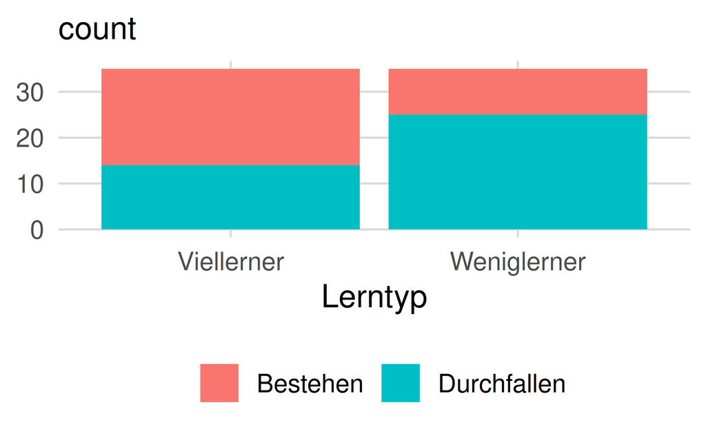

Hier ist die Kontingenztabelle mit den Häufigkeiten pro Gruppe:

| Lerntyp | Bestehen | Durchfallen |
| --- | --- | --- |
| Weniglerner | 10 | 25 |
| Viellerner | 21 | 14 |

*Berechnen Sie die folgende* gemeinsame Wahrscheinlichkeit*: p(Bestehen UND Weniglerner). Wählen Sie die richtige Antwortoption.*

0.860.360.140.290.3

Die gemeinsame Wahrscheinlichkeit berechnet sich als der Quotient der Zellenhäufigkeit und der Gesamthäufigkeit:

$Pr(Bestehen \cap Weniglerner) = \frac{n(Bestehen \cap Weniglerner)}{n_{gesamt}} = \frac{10}{70} = 0.14$

Die falschen Optionen entstehen durch typische Verwechslungen: die bedingte statt der gemeinsamen Wahrscheinlichkeit, die gemeinsame Wahrscheinlichkeit des jeweils anderen Klausurergebnisses bzw. der anderen Lerngruppe, sowie das naive Komplement (1 − Lösung).

- False
- False
- True
- False
- False

Ein renommiertes Unternehmen sucht einen Kandidaten für eine (hoch dotierte) Führungsposition. Ein Managementberatungsunternehmung führt ein Assessmentcenter durch, welches pro Kandidat/in eine positive bzw. negative Empfehlung ergibt. Aus früheren Erfahrungen heraus wissen die Berater, dass die tatsächlich geeigneten Kandidaten (Ereignis $E$ wie *eligible*) mit $60\%$ eine positive Empfehlung für die Stelle ausgesprochen bekommen (Ereignis $R$ wie *recommendation*). Weiterhin bekommen von den *nicht* geeigneten Kandidaten $72\%$ eine negative Empfehlung. Insgesamt wissen die Berater, dass $10\%$ der Bewerber/innen tatsächlich geeignet sind.

**Aufgabe:** Was ist die entsprechende Häufigkeitstabelle? Wählen Sie die Antwortoption, die alle vier gemeinsamen Wahrscheinlichkeiten (in Prozent) korrekt angibt.

*Hinweis*: Das Gegenereignis vom Ereignis $A$ wird als Komplementärereignis oder kurz als Komplement bezeichnet und mit $A^C$ oder $\overline{A}$ abgekürzt. Im vorliegenden Fall meint $\overline{R}=R^C$ das Ereignis, dass ein Kandidat *keine* Empfehlung ausgesprochen bekommt.

$P(E \cap R) = 4.00\%$, $P(\overline{E} \cap R) = 64.80\%$, $P(E \cap \overline{R}) = 6.00\%$, $P(\overline{E} \cap \overline{R}) = 25.20\%$$P(E \cap R) = 6.00\%$, $P(\overline{E} \cap R) = 25.20\%$, $P(E \cap \overline{R}) = 4.00\%$, $P(\overline{E} \cap \overline{R}) = 64.80\%$$P(E \cap R) = 25.20\%$, $P(\overline{E} \cap R) = 6.00\%$, $P(E \cap \overline{R}) = 64.80\%$, $P(\overline{E} \cap \overline{R}) = 4.00\%$$P(E \cap R) = 64.80\%$, $P(\overline{E} \cap R) = 4.00\%$, $P(E \cap \overline{R}) = 25.20\%$, $P(\overline{E} \cap \overline{R}) = 6.00\%$0

Einige Wahrscheinlichkeiten lassen sich direkt aus dem Text errechnen:

$$\begin{aligned}
P(E \cap R) & =
P(R | E) \cdot P(E) = 0.6 \cdot 0.1 = 0.06 = 6\%\\
P(\overline{E} \cap \overline{R}) & =
P(\overline{R} | \overline{E}) \cdot P(\overline{E}) = 0.72 \cdot 0.9 = 0.65 = 64.8\%.
\end{aligned}$$

Die restlichen gemeinsamen Wahrscheinlichkeiten lassen sich durch Addieren und Subtrahieren in der Kontingenztabelle errechnen:

|  | $R$ | $\overline{R}$ | Summe |
| --- | --- | --- | --- |
| $E$ | **6.00** | *4.00* | **10.00** |
| $\overline{E}$ | *25.20* | **64.80** | *90.00* |
| Summe | *31.20* | *68.80* | **100.00** |

Die falschen Antwortoptionen entstehen durch vertauschte Zeilen und/oder Spalten der Kontingenztafel (Verwechslung von $E$/$\overline{E}$ bzw. $R$/$\overline{R}$).

- False
- True
- False
- False
- False

Betrachten wir das Zufallsexperiment, bei dem ein Würfel geworfen wird. Wir haben keinen Grund zu glauben, dass eine bestimmte Augenzahl bevorzugt wird, und nehmen daher an, dass alle Augenzahlen gleich wahrscheinlich sind.

Sei $A$ das Ereignis, dass eine gerade Zahl geworfen wird. Sei $B$ das Ereignis, dass eine Zahl größer als 3 geworfen wird.

Was ist die Wahrscheinlichkeit für das Ereignis $A \cap B$, also das gemeinsame Eintreten von $A$ und $B$?

$\frac{1}{3}$$\frac{1}{2}$$\frac{1}{6}$$\frac{2}{3}$$\frac{1}{4}$

```
a <- c(2, 4, 6)
b <- c(4, 5, 6)

intersect(a, b)
## [1] 4 6
```

Die Schnittmenge von $A$ und $B$ ist also $\{4,6\}$, also die Menge der geraden Zahlen, die größer als 3 sind. Das sind 2 von 6 möglichen Ergebnissen, also ist die Wahrscheinlichkeit $P(A \cap B) = \frac{2}{6} = \frac{1}{3}$.

Die Distraktoren entstehen durch typische Fehler: $\frac{2}{3}$ (Vereinigung $A \cup B$ statt Schnitt), $\frac{1}{2}$ (nur Einzelereignis $A$ bzw. $B$), $\frac{1}{6}$ (Schnittmenge fälschlich als einelementig angenommen), $\frac{1}{4}$ (naive Multiplikation $P(A) \cdot P(B)$ unter der falschen Annahme der Unabhängigkeit).

- True
- False
- False
- False
- False

Wissenschaft! Vielleicht das wichtigste Projekt der Menschheit, geht es doch um die Loslöung von “Du musst das glauben, weil ich es sage” hin zu “Ich glaube das, weil ich es verstehe”.

Sei 1 % aller Studien der Wissenschaft “genial”. Ein Gutachter prüft eine wissenschaftliche Studie und erkennt 90 % der genialen Studien als solche. Allerdings stuft der Gutachter auch 10 % der nicht-genialen Studien fälschlich als genial ein. Nach der Prüfung der Studie ist der Gutachter überzeugt, dass die Studie genial ist.

*Aufgabe*: Berechnen Sie die Wahrscheinlichkeit, dass die Studie wirklich genial ist.

0.080.10.90.010.92

Gegeben ist:

```
Pr_g
## [1] 0.01
```

```
Pr_t_geg_g
## [1] 0.9
```

Hier kann man Bayes’ Theorem anwenden:

$Pr(g|t) = \frac{Pr(g) \cdot Pr(t|g) }{Pr(t)}$.

Zähler: 0.01

Nenner: 0.11

Bruch: 0.08

Die Lösung beträgt also: 0.08.

Hier ist ein Baumdiagramm zur Visualisierung:

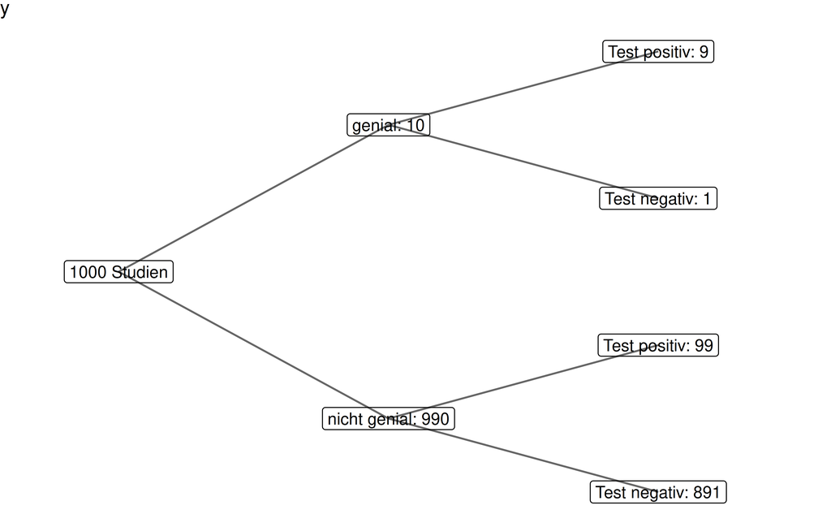

Es erhalten 108=99+9 Studien ein positives Testergebnis: “geniale Studie!” Davon sind 9 tatsächlich genial. Das ist ist ein Anteil von $\frac{9}{108} = 0.0833$.

Also: $Pr(g|t) = \frac{9}{108} = 0.0833$.

Alternativ kann man auch mit der Bayesbox arbeiten:

[output not shown]

Die Likelihood für die Hypothese $g$ (die Hypothese, dass die Studie genial ist) ist definiert als $Pr(D|H)=0.9$. Hier entspricht der positive Genialitätstest den Daten.

Die unstandardisierte Post-Wahrscheinlichkeit entspricht dem Produkt aus Likelihood und Priori: $Pr(D|H) \cdot Pr(H)=0.009$ bzw. $0.099$.

Die Evidenz ist die Summe der Posterior-Wahrscheinlichkeiten multipliziert mit den jeweiligen Prioris: $Pr(D)=0.108$.

Die Post-Wahrscheinlichkeit ist die durch die Evidenz dividierte unstandardisierte Post-Wahrscheinlichkeit: $Pr(H|D)= 0.009 / 0.108 = 0.083$ (bzw. für “nicht-genial”: $0.917$).

Die Distraktoren entstehen durch typische Bayes-Fehler: Verwechslung mit der Likelihood $Pr(t|g)=0.9$ (Base-Rate-Neglect), Verwechslung mit dem Priori $Pr(g)=0.01$, das Komplement $1-Pr(g|t)$, sowie die falsch-positiv-Rate $1-Pr(t|g)=0.1$.

- True
- False
- False
- False
- False

Wir werfen einen Globus $n=9$ Mal und erzielen $W=9$ mal das Ereignis “Wasser”.

Was ist die Wahrscheinlichkeit dieses Ereignisses, wenn wir von einer Wasseranteil, d. h. Wahrscheinlichkeit, von $\pi=0.7$ ausgehen?

0.040.9600.140.7

Gegeben sind die Werte $W=9$, $n=9$, $\pi=0.7$. Wir suchen also diese Größe:

$$Pr(W=9 | \pi=0.7, n=9) = ?$$

Wir können R die Arbeit machen lassen:

```
dbinom(x = W, size = n, prob = pi)
## [1] 0.04
```

Oder den Taschenrechner nutzen:

```
choose(n,W) * pi^W * (1-pi)^(n-W)
## [1] 0.04
```

Die Harten unter uns rechnen es per Hand aus. Dafür kann man zunächst die Anzahl der Pfade mit dem Binomialkoeffizienten berechnen:

```
anzahl_pfade <- factorial(n) / (factorial(W) * factorial(n-W))
anzahl_pfade
## [1] 1
```

`factorial(W)` liefert die Fakultät von $W$ zurück.

Dann berechnet man die Wahrscheinlichkeit eines einzelnen Pfades:

```
pfad_wskt <-  pi^W * (1-pi)^(n-W)
pfad_wskt
## [1] 0.04
```

Multipliziert man die beiden vorherigen Zwischenergebnisse, so erhält man die Lösung: 0.04.

Die Distraktoren entstehen durch typische Fehler: $\pi$ direkt als Antwort verwendet (ohne Potenzieren), das Komplement $1 - Pr(W=9)$, sowie die falsche Basis $(1-\pi)^W$ (Wasseranteil und Gegenanteil vertauscht).

Die “0.14” ist ein willkürlicher Distraktor.

- True
- False
- False
- False
- False

Für Statistiken (Stichprobe) verwendet man meist lateinische Buchstaben; für Parameter (Population) verwendet man meist (die entsprechenden) griechischen Buchstaben.

| Kennwert | Statistik | Parameter |
| --- | --- | --- |
| Mittelwert | $\bar{X}$ | NA |
| Mittelwertsdifferenz | $\bar{X}_1-\bar{X}_2$ | NA |
| Streuung | sd | NA |
| Anteil | p | NA |
| Korrelation | r | NA |
| Regressionsgewicht | b | NA |

*Welche Antwortoption vervollständigt folgende Tabelle korrekt?*

Mittelwert: $\sigma$, Mittelwertsdifferenz: $\mu_1-\mu_2$, Streuung: $\mu$, Anteil: $\pi$, Korrelation: $\beta$, Regressionsgewicht: $\rho$Mittelwert: $\mu$, Mittelwertsdifferenz: $\mu_1-\mu_2$, Streuung: $\sigma$, Anteil: $\pi$, Korrelation: $\beta$, Regressionsgewicht: $\rho$Mittelwert: $\mu$, Mittelwertsdifferenz: $\mu_1-\mu_2$, Streuung: $\sigma$, Anteil: $\pi$, Korrelation: $\rho$, Regressionsgewicht: $\beta$Mittelwert: $\mu$, Mittelwertsdifferenz: $\mu_1-\mu_2$, Streuung: $\pi$, Anteil: $\sigma$, Korrelation: $\rho$, Regressionsgewicht: $\beta$Mittelwert: $\sigma$, Mittelwertsdifferenz: $\mu_1-\mu_2$, Streuung: $\mu$, Anteil: $\pi$, Korrelation: $\rho$, Regressionsgewicht: $\beta$

Die korrekte Zuordnung von Statistik (Stichprobenkennwert) zu Parameter (Populationskennwert) lautet:

| Kennwert | Statistik | Parameter |
| --- | --- | --- |
| Mittelwert | $$\bar{X}$$ | $$\mu$$ |
| Mittelwertsdifferenz | $$d=\bar{X}_1-\bar{X}_2$$ | $$\mu_1$$ - $$\mu_2$$ |
| Streuung | sd | $$\sigma$$ |
| Anteil | p | $$\pi$$ |
| Korrelation | r | $$\rho$$ |
| Regressionsgewicht | b | $$\beta$$ |

Die falschen Optionen entstehen durch typische Verwechslungen: Streuung ($\sigma$) und Anteil ($\pi$) vertauscht, Korrelation ($\rho$) und Regressionsgewicht ($\beta$) vertauscht, sowie Mittelwert ($\mu$) und Streuung ($\sigma$) vertauscht.

- False
- False
- True
- False
- False

Übersetzen Sie folgende Forschungsfrage in die korrekte Regressionsformel!

*Gibt es einen Interaktionseffekt zwischen Geschlecht und Schnabellänge auf das Gewicht eines Pinguins? Liegen auch Haupteffekte vor?*

Welche Regressionsformel ist korrekt?

`body_mass_g ~ sex:bill_length_mm``body_mass_g ~ sex * bill_length_mm * species``body_mass_g ~ sex + bill_length_mm``body_mass_g ~ sex + bill_length_mm + species:bill_length_mm``body_mass_g ~ sex + bill_length_mm + sex:bill_length_mm`

Die Regressionsformel lautet: `body_mass_g ~ sex + bill_length_mm + sex:bill_length_mm`. Sie enthält beide Haupteffekte (`sex`, `bill_length_mm`) sowie den Interaktionsterm (`sex:bill_length_mm`) und hat `body_mass_g` korrekt als abhängige Variable.

- False
- False
- False
- False
- True

Betrachten Sie folgende Forschungsformel:

> Gibt es einen Interaktionseffekt zwischen Geschlecht und Schnabellänge auf das Gewicht eines Pinguins? Liegen auch Haupteffekte vor?

Auf Basis der folgenden Analyse ist folgende Frage zu untersuchen. Liegt ein Interaktionseffekt vor?

Zur besseren Interpretierbarkeit sind die metrischen UV standardisiert:

```
penguins_z <- standardize(penguins, select = c(bill_length_mm), append = TRUE)
```

Es werden verschiedene Modelle berechnet, die sich in ihrer Regressionsformel unterscheiden:

```
m1 <- stan_glm(body_mass_g ~ sex, data = penguins_z)
m2 <- stan_glm(body_mass_g ~ sex + bill_length_mm_z, data = penguins_z)
m3 <- stan_glm(body_mass_g ~ sex + bill_length_mm_z + sex:bill_length_mm_z,
               data = penguins_z)
m4 <- stan_glm(body_mass_g ~ sex:bill_length_mm_z, data = penguins_z)
m5 <- stan_glm(bill_length_mm_z ~ sex + body_mass_g + sex:body_mass_g, data = penguins_z)
```

Hier sind die Modellparameter (Punktschätzer als Median sowie 95 %-ETI):

| Modell | Median | CI_low | CI_high |
| --- | --- | --- | --- |
| m1 | 3864 | 3753 | 3978 |
| m2 | 4003 | 3907 | 4100 |
| m3 | 4012 | 3908 | 4116 |
| m4 | 4220 | 4144 | 4296 |
| m5 | 26 | 22 | 30 |

*Welches Modell ist korrekt spezifiziert, um die Forschungsfrage (Interaktionseffekt und Haupteffekte) zu beantworten?*

`m2`: `body_mass_g ~ sex + bill_length_mm_z``m5`: `bill_length_mm_z ~ sex + body_mass_g + sex:body_mass_g``m1`: `body_mass_g ~ sex``m3`: `body_mass_g ~ sex + bill_length_mm_z + sex:bill_length_mm_z``m4`: `body_mass_g ~ sex:bill_length_mm_z`

Die Regressionsformel lautet: `body_mass_g ~ sex + bill_length_mm_z + sex:bill_length_mm_z`. Daher ist `m3` korrekt, da sie beide Haupteffekte (`sex`, `bill_length_mm`) sowie den Interaktionsterm enthält.

Die Parameterwerte von `m3` zeigen, dass ein Interaktionseffekt nicht bestätigt werden kann, bzw. dass die Null, also keine Interaktion, im Bereich plausibler Werte (d. h. innerhalb des Konfidenzintervalls) liegt.

- False
- False
- False
- True
- False

Beurteilen Sie folgende Aussagen: *Man kann die Forschungsfrage, ob sich zwei Gruppen (Populationen) hinsichtlich ihres Mittelwerts unterscheiden, mit einem t-Test oder einer Regressionsanalyse untersuchen.*

Wählen Sie die korrekte Antwortoption!

Ja, beide Verfahren sind analog, aber die Regression hat Vorzüge.Nein, eine Regression setzt intervallskalierte Prädiktoren voraus, daher ist sie hier nicht anwendbar.Nein, eine Regression kann nur bei mehr als zwei Gruppen verwendet werden.Nein, man sollte die Regression generell nicht verwenden.Ja, aber die Regression ist numerisch instabil und sollte daher nicht verwendet werden.

- True
- False
- False
- False
- False

Welche der folgenden Aussagen zur Interpretation eines Populationsparameters (z. B. $\mu$) eines Konfidenzintervalls der Art `95% CI [182cm; 184cm]` ist richtig bzw. passt am besten?

> Mit 95 % Wahrscheinlichkeit liegt der wahre Wert des zugrundeliegenden Parameters zwischen 182 cm und 184 cm.

Bedeutet, dass 95 % aller Messwerte der Population zwischen 182 cm und 184 cm liegenPasst weder zur Frequentistischen, noch zur Bayesianischen StatistikPasst nur zur Bayesianischen, nicht zur Frequentistischen StatistikPasst nur zur Frequentistischen, nicht zur Bayesianischen StatistikPasst sowohl zur Frequentistischen, als auch zur Bayesianischen Statistik

Passt nur zur Bayesianischen, nicht zur Frequentistischen Statistik.

- False
- False
- True
- False
- False

Betrachten Sie dieses Modell, das den Zusammenhang von PS-Zahl (`hp`: horse power) und Spritverbrauch (`mpg`: miles per Gallone) untersucht (Datensatz `mtcars`):

```
data(mtcars)
library(rstanarm)
library(easystats)
lm1 <- stan_glm(mpg ~ hp, data = mtcars,
                refresh = 0)
```

| Parameter | Median | 95% CI |
| --- | --- | --- |
| (Intercept) | 30.11 | (26.89, 33.43) |
| hp | -0.07 | (-0.09, -0.05) |

*Wie ist der Effekt von $\beta_1$ (hp) im Modell am besten zu interpretieren?*

Die Korrelation zwischen PS-Zahl und Spritverbrauch beträgt 0.1Der PS-Wert erklärt 0.1 % der Varianz im SpritverbrauchEin Auto mit einem PS mehr verbraucht 0.1 Gallonen mehr Sprit pro gefahrener MeileBei einem PS-Wert von 0 beträgt der geschätzte mittlere Spritverbrauch 0.1 Meilen pro GalloneEin Auto mit einem PS mehr kommt im Mittel ca. 0.1 (0.07) Meilen weniger weit mit einer Gallone Sprit, laut diesem Modell

*hp* ($\beta_1$) ist der Regressionskoeffizient und gibt den statistischen “Effekt” der PS-Zahl auf den Spritverbrauch an. Vorsicht: Dieser “Effekt” darf nicht vorschnell als kausaler Effekt verstanden werden. Vorsichtiger wäre zu sagen: “Ein Auto mit einem PS mehr, kommt im Mittel 0.1 (0.07) Meilen weniger weit mit einer Gallone Sprit, laut diesem Modell.” Den Punktschätzer des Regressionskoeffizienten kann man in der Parametertabelle in der Spalte `Median` auslesen.

Die Regressionsformel lautet: `mpg ~ hp`.

- False
- False
- False
- False
- True

Weltsensation?! Der Insektenforscher Prof. Mügge ist der Meinung, eine bislang unbekannte Käferart entdeckt zu haben. Nach nur 18 Jahren Feldforschung im brasilianischen Regenwald gelang ihm dieser Durchbruch. Wenn es denn nun wirklich eine neue Art ist. Gerade untersucht er ein Exemplar unter dem Mikroskop. Hm, was ist das für ein Tier?

Drei Arten kommen in Frage, $A_1, A_2, A_3$.

Dabei ist die Art $A_1$ sehr verbreitet und schon längst bekannt, $A_2$ ist die neue Art, Exemplare dieser Art sind selten und $A_3$ ist auch bekannt und eher häufig anzutreffen. Allerdings spricht das Aussehen am ehesten für $A_2$, der seltenen Art.

Hier sind die genauen Vorkommenshäufigkeiten:

```
Pr_A1 <- .6
Pr_A2 <- .1
Pr_A3 <- .3
```

Und hier die genauen Wahrscheinlichkeiten, wie typisch das beobachtete Objekt für einen Vertreter der jeweiligen Art ist:

```
L_A1 <- .5
L_A2 <- .9
L_A3 <- .4
```

*Wie groß ist die Wahrscheinlichkeit, dass Prof. Mügge wirklich einen großen Fang gemacht hat und einen unbekannten Käfer entdeckt hat?* Berechnen Sie diese Wahrscheinlichkeit!

50 %17.6 %23.1 %10 %90 %

```
library(tidyverse)
library(prada)  # für Funktion `bayesbox`

bb <- bayesbox(hyps = c("A", "B", "C"),
               priors = c(Pr_A1, Pr_A2, Pr_A3),
               liks = c(L_A1, L_A2, L_A3))

bb
```

| hyps | priors | liks | post_unstand | post_std |
| --- | --- | --- | --- | --- |
| A | 0.6 | 0.5 | 0.30 | 0.59 |
| B | 0.1 | 0.9 | 0.09 | 0.18 |
| C | 0.3 | 0.4 | 0.12 | 0.24 |

Die Wahrscheinlichkeit, dass der Käfer zur Art “B” (also $A_2$) gehört, ist relativ klein: 17.6 %. Man erhält sie durch Anwendung des Satzes von Bayes: Priori × Likelihood, normiert durch die Summe aller Priori × Likelihood-Produkte: $(0.1 \times 0.9) / (0.6\times.5 + 0.1\times.9 + 0.3\times.4) = 0.09/.51 = 0.176$.

- False
- True
- False
- False
- False

In *Think Bayes* stellt Allen Downey folgende Aufgabe:

“Angenommen, es gibt zwei Schüsseln mit Keksen.

Schüssel 1 enthält 30 Vanillekekse und 10 Schokoladenkekse.

Schüssel 2 enthält 20 Vanillekekse und 20 Schokoladenkekse.

Nehmen Sie nun an, Sie wählen zufällig eine der beiden Schüsseln aus und ziehen daraus, ohne hinzusehen, zufällig einen Keks.

*Wenn der Keks Vanille ist, wie groß ist die Wahrscheinlichkeit, dass er aus Schüssel 1 stammt?*”

*Wählen Sie die korrekte Antwort!*

0.330.400.750.500.60

```
library(tidyverse)

d <-
  tibble(
    p_Gitter = c(1, 2),
    Priori  = .5) %>%
    mutate(
      Likelihood = c(3/4, 2/4),
      unstd_Post = Likelihood * Priori,
      Evidenz = sum(unstd_Post),
      Post = unstd_Post / sum(unstd_Post))

d %>%
  knitr::kable(digits=2)
```

| p_Gitter | Priori | Likelihood | unstd_Post | Evidenz | Post |
| --- | --- | --- | --- | --- | --- |
| 1 | 0.5 | 0.75 | 0.38 | 0.62 | 0.6 |
| 2 | 0.5 | 0.50 | 0.25 | 0.62 | 0.4 |

Die Antwort lautet **0.60**. Es ist übrigens egal, ob Sie für die Priori-Werte 0.5 oder 1 (oder eine andere Zahl) wählen, solange Sie für alle Hypothesen die gleiche Zahl verwenden – das Ergebnis bleibt dann gleich.

- False
- False
- False
- False
- True

Eine Studentin hat zwei Klausuren, $A$ und $B$ geschrieben. Sie schätzt ihre Chancen zu bestehen auf 35 % bzw. auf 60 %. Unterstellen Sie Unabhängigkeit der Ereignisse.

```
Pr_A <- .35
Pr_B <- .6
```

*Wie groß ist die Chance, mindestens eine der beiden Klausuren zu bestehen?*

26 %74 %95 %60 %21 %

Es gibt mehrere Wege, die Aufgabe zu lösen: die direkte Berechnung, die Gegenwahrscheinlichkeit (1 minus die Wahrscheinlichkeit, beide durchzufallen), oder über den Additionssatz ($Pr_A + Pr_B - Pr_{AB}$).

```
Pr_A <- .35
Pr_B <- .6
Pr_AB <- Pr_A * Pr_B
Pr_mind1_bestanden <- 1 - (1 - Pr_A) * (1 - Pr_B)
Pr_mind1_bestanden
## [1] 0.74
```

Die Lösung lautet **74 %**.

Die Distrkatoren sind willkürlich gewählt.

- False
- True
- False
- False
- False

Ein Krebstest ($T$) hat die Wahrscheinlichkeit 0.9, einen vorhandenen Krebs ($K$) zu erkennen: $Pr(T+|K+)$. Die Falsch-Positiv-Rate beträgt 0.05: $Pr(T+|K-)$. Die Grundrate dieser Krebsart liegt bei 0.01: $Pr(K+)$.

Berechnen Sie die Wahrscheinlichkeit, dass ein Patient tatsächlich Krebs hat, wenn der Test positiv ist: $Pr(K+|T+)$.

0.170.180.010.850.15

$$Pr(K+|T+) = \frac{Pr(T+|K+) \cdot Pr(K+)}{Pr(T+|K+) \cdot Pr(K+) + Pr(T+|K-) \cdot Pr(K-)} = \frac{0.9 \cdot 0.01}{0.9 \cdot 0.01 + 0.05 \cdot 0.99} = 0.15$$

- Falsch
- Falsch
- Falsch
- Falsch
- Wahr

## 16.3 2024

1. [ttest-als-regr](https://sebastiansauer.github.io/datenwerk/posts/ttest-als-regr/ttest-als-regr.html)
2. [Additionssatz1](https://sebastiansauer.github.io/datenwerk/posts/additionssatz1/additionssatz1)
3. [Nerd-gelockert](https://sebastiansauer.github.io/datenwerk/posts/nerd-gelockert/nerd-gelockert)
4. [Urne1](https://sebastiansauer.github.io/datenwerk/posts/urne1/urne1)
5. [corona-blutgruppe](https://sebastiansauer.github.io/datenwerk/posts/corona-blutgruppe/corona-blutgruppe.html)
6. [voll-normal](https://sebastiansauer.github.io/datenwerk/posts/voll-normal/index.html)
7. [alphafehler-inflation3](https://sebastiansauer.github.io/datenwerk/posts/alphafehler-inflation3/alphafehler-inflation3.html)
8. verteilungen-quiz-05
9. verteilungen-quiz-03
10. verteilungen-quiz-04
11. [Kekse03](https://sebastiansauer.github.io/datenwerk/posts/kekse03/index.html)
12. [globus-bin2](https://sebastiansauer.github.io/datenwerk/posts/globus-bin2/)
13. [globus2](https://sebastiansauer.github.io/datenwerk/posts/globus2/)
14. [iq01a](https://sebastiansauer.github.io/datenwerk/posts/iq01a/)
15. [gem-wskt4](https://sebastiansauer.github.io/datenwerk/posts/gem-wskt4/)
16. [Rethink2m3](https://sebastiansauer.github.io/datenwerk/posts/rethink2m3/rethink2m3)
17. [mtcars-post2a](https://sebastiansauer.github.io/datenwerk/posts/mtcars-post2a/)
18. [groesse03](https://sebastiansauer.github.io/datenwerk/posts/groesse03/)
19. [bath42](https://sebastiansauer.github.io/datenwerk/posts/bath42/bath42.html)
20. klausur-raten
21. bed-post-wskt1
22. [mtcars-post3a](https://sebastiansauer.github.io/datenwerk/posts/mtcars-post3a/)
23. [exp-tab](https://sebastiansauer.github.io/datenwerk/posts/exp-tab/)
24. [norms-sd](https://sebastiansauer.github.io/datenwerk/posts/norms-sd/)
25. [mtcars-post_paper](https://sebastiansauer.github.io/datenwerk/posts/mtcars-post_paper/)
26. [bfi10](https://sebastiansauer.github.io/datenwerk/posts/bfi10/)
27. [rope-luecke](https://sebastiansauer.github.io/datenwerk/posts/rope-luecke/)
28. [wskt-schluckspecht2a](https://sebastiansauer.github.io/datenwerk/posts/wskt-schluckspecht2a/)
29. [penguins-stan-06](https://sebastiansauer.github.io/datenwerk/posts/penguins-stan-06/index.html)

## 16.4 2023

[Dieser Tag auf dem Datenwerk](https://sebastiansauer.github.io/datenwerk/#category=qm2-pruefung) stellt Fragen einer Probeprüfung (Version 2023) zusammen.

## 16.5 2022

[Dieser Tag auf dem Datenwerk](https://sebastiansauer.github.io/datenwerk/#category=exam-22) stellt Fragen einer Probeprüfung (Version 2022) zusammen.